# Project: Wrangle and analyze data

- Introduction
- Gathering data
- Assessing data
- Cleaning data
- Storing data
- Exploratory Data Analysis - EDA

## Introduction

This academic project aims to wrangle data from [@dog_rates](https://twitter.com/dog_rates) Twitter, also known as WeRateDogs, create interesting and trustworthy analyses and visualizations. Additional gathering, then assessing and cleaning is required for "Wow!"-worthy analyses and visualizations.

Find below main tasks:

1. Data wrangling, which consists of:

   1.1. Gathering data (downloadable files and querying Twitter API).

   1.2. Assessing data;

   1.3. Cleaning data;
1. Storing, analyzing, and visualizing the wrangled data;
1. Communication and Reporting on my data wrangling efforts, data analysys and visualizations, as well.

```python
#Installing tweepy this command:
!pip install tweepy
```

```python
# Import libraries
import tweepy
import pandas as pd
import numpy as np
import requests
import json
import time
import matplotlib.pyplot as plt
```

```python
# Accessing Tweepy keys and token

consumer_key = 'EFGolc9OVWikDK7wuWLJtFwQo'
consumer_secret = 'A0Swo3FXPWsScOfKaRogASOljDp9tDIy9lxBB7A7mo9pgp2KVT'
access_token = '1260883091566080000-RPdofde6tnGpiBwWrEyhPxz5uP4QQx'
access_secret = 'LJ1jeyCSidxP0PpGbfpPeZPzi52En7bLkF4BiKgI712U5'

auth = tweepy.OAuthHandler(consumer_key, consumer_secret)
auth.set_access_token(access_token, access_secret)

# Wait_on_rate_limit and wait_on_rate_limit_notify are recommended
api = tweepy.API(auth, wait_on_rate_limit=True, wait_on_rate_limit_notify=True)
```

## Gathering Data

In this project I'm going to work with the data below:

   1.1. DogoDictionary:

   ```
     doggo - a big pupper, usually older;
     pupper - a small doggo, usually younger;
     puppo - a transitional phase between doggo to pupper;
     blep - one's tongue protuding ever so slightly from the mouth as an extremely subtle act that occurs;
     snoot - the dog's nose;
     floof - any dog really.
   ```

1. The tweet image predictions: **image-predictions.tsv**
1. Using the tweet IDs in the WeRateDogs Twitter archive, I'm going to query the Twitter API for each tweet's JSON data using Python's Tweepy library and store each tweet's entire set of JSON data in a file called tweet_json.txt file. Each tweet's JSON data should be written to its own line. Then read this .txt file line by line into a pandas DataFrame with (at minimum) tweet ID, retweet count, and favorite count.

```python
#Reading the We Rate Dogs Twitter Archive
archive = pd.read_csv('dataset/twitter-archive-enhanced-2.csv')
archive.head(5)
```

|  | tweet_id | in_reply_to_status_id | in_reply_to_user_id | timestamp | source | text | retweeted_status_id | retweeted_status_user_id | retweeted_status_timestamp | expanded_urls | rating_numerator | rating_denominator | name | doggo | floofer | pupper | puppo |
| --- | --- | --- | --- | --- | --- | --- | --- | --- | --- | --- | --- | --- | --- | --- | --- | --- | --- |
| 0 | 892420643555336193 | NaN | NaN | 2017-08-01 16:23:56 +0000 | <a href="http://twitter.com/download/iphone" r... | This is Phineas. He's a mystical boy. Only eve... | NaN | NaN | NaN | https://twitter.com/dog_rates/status/892420643... | 13 | 10 | Phineas | None | None | None | None |
| 1 | 892177421306343426 | NaN | NaN | 2017-08-01 00:17:27 +0000 | <a href="http://twitter.com/download/iphone" r... | This is Tilly. She's just checking pup on you.... | NaN | NaN | NaN | https://twitter.com/dog_rates/status/892177421... | 13 | 10 | Tilly | None | None | None | None |
| 2 | 891815181378084864 | NaN | NaN | 2017-07-31 00:18:03 +0000 | <a href="http://twitter.com/download/iphone" r... | This is Archie. He is a rare Norwegian Pouncin... | NaN | NaN | NaN | https://twitter.com/dog_rates/status/891815181... | 12 | 10 | Archie | None | None | None | None |
| 3 | 891689557279858688 | NaN | NaN | 2017-07-30 15:58:51 +0000 | <a href="http://twitter.com/download/iphone" r... | This is Darla. She commenced a snooze mid meal... | NaN | NaN | NaN | https://twitter.com/dog_rates/status/891689557... | 13 | 10 | Darla | None | None | None | None |
| 4 | 891327558926688256 | NaN | NaN | 2017-07-29 16:00:24 +0000 | <a href="http://twitter.com/download/iphone" r... | This is Franklin. He would like you to stop ca... | NaN | NaN | NaN | https://twitter.com/dog_rates/status/891327558... | 12 | 10 | Franklin | None | None | None | None |

```python
# Requesting tweet image predictions file
with open('image_predictions.tsv' , 'wb') as file:
    image_predictions = requests.get('https://d17h27t6h515a5.cloudfront.net/topher/2017/August/599fd2ad_image-predictions/image-predictions.tsv', auth=('user', 'pass'))
    file.write(image_predictions.content)
```

```python
# Reading image predictions
image_predictions = pd.read_csv('image_predictions.tsv', sep='\t')
image_predictions.head()
```

|  | tweet_id | jpg_url | img_num | p1 | p1_conf | p1_dog | p2 | p2_conf | p2_dog | p3 | p3_conf | p3_dog |
| --- | --- | --- | --- | --- | --- | --- | --- | --- | --- | --- | --- | --- |
| 0 | 666020888022790149 | https://pbs.twimg.com/media/CT4udn0WwAA0aMy.jpg | 1 | Welsh_springer_spaniel | 0.465074 | True | collie | 0.156665 | True | Shetland_sheepdog | 0.061428 | True |
| 1 | 666029285002620928 | https://pbs.twimg.com/media/CT42GRgUYAA5iDo.jpg | 1 | redbone | 0.506826 | True | miniature_pinscher | 0.074192 | True | Rhodesian_ridgeback | 0.072010 | True |
| 2 | 666033412701032449 | https://pbs.twimg.com/media/CT4521TWwAEvMyu.jpg | 1 | German_shepherd | 0.596461 | True | malinois | 0.138584 | True | bloodhound | 0.116197 | True |
| 3 | 666044226329800704 | https://pbs.twimg.com/media/CT5Dr8HUEAA-lEu.jpg | 1 | Rhodesian_ridgeback | 0.408143 | True | redbone | 0.360687 | True | miniature_pinscher | 0.222752 | True |
| 4 | 666049248165822465 | https://pbs.twimg.com/media/CT5IQmsXIAAKY4A.jpg | 1 | miniature_pinscher | 0.560311 | True | Rottweiler | 0.243682 | True | Doberman | 0.154629 | True |

```python
# Collecting data using API

# Calculate the time of execution
start = time.time()

# Storing ID data in OK or NOK if error
ok =[]
nok = []

with open('tweet_json.txt', 'w') as file:
    for tweet_id in list(archive['tweet_id']):
        try:
            tweet_status = api.get_status(tweet_id,tweet_mode='extended')
            json.dump(tweet_status._json, file)
            file.write('\n')
            ok.append(tweet_id)
        except Exception as e:
            print(str(tweet_id)+ " _ " + str(e))
            nok.append(tweet_id)

end = time.time()
print(end - start)
```

```
888202515573088257 _ [{'message': 'No status found with that ID.', 'code': 144}]
873697596434513921 _ [{'message': 'No status found with that ID.', 'code': 144}]
872668790621863937 _ [{'message': 'No status found with that ID.', 'code': 144}]
872261713294495745 _ [{'message': 'No status found with that ID.', 'code': 144}]
869988702071779329 _ [{'message': 'No status found with that ID.', 'code': 144}]
866816280283807744 _ [{'message': 'No status found with that ID.', 'code': 144}]
861769973181624320 _ [{'message': 'No status found with that ID.', 'code': 144}]
856602993587888130 _ [{'message': 'No status found with that ID.', 'code': 144}]
851953902622658560 _ [{'message': 'No status found with that ID.', 'code': 144}]
845459076796616705 _ [{'message': 'No status found with that ID.', 'code': 144}]
844704788403113984 _ [{'message': 'No status found with that ID.', 'code': 144}]
842892208864923648 _ [{'message': 'No status found with that ID.', 'code': 144}]
837366284874571778 _ [{'message': 'No status found with that ID.', 'code': 144}]
837012587749474308 _ [{'message': 'No status found with that ID.', 'code': 144}]
829374341691346946 _ [{'message': 'No status found with that ID.', 'code': 144}]
827228250799742977 _ [{'message': 'No status found with that ID.', 'code': 144}]
812747805718642688 _ [{'message': 'No status found with that ID.', 'code': 144}]
802247111496568832 _ [{'message': 'No status found with that ID.', 'code': 144}]
779123168116150273 _ [{'message': 'No status found with that ID.', 'code': 144}]
775096608509886464 _ [{'message': 'No status found with that ID.', 'code': 144}]
771004394259247104 _ [{'message': 'Sorry, you are not authorized to see this status.', 'code': 179}]
770743923962707968 _ [{'message': 'No status found with that ID.', 'code': 144}]
759566828574212096 _ [{'message': 'No status found with that ID.', 'code': 144}]
```

```
Rate limit reached. Sleeping for: 721
```

```
758740312047005698 _ Failed to send request: HTTPSConnectionPool(host='api.twitter.com', port=443): Max retries exceeded with url: /1.1/statuses/show.json?tweet_mode=extended&id=758740312047005698 (Caused by ProxyError('Cannot connect to proxy.', RemoteDisconnected('Remote end closed connection with…
754011816964026368 _ [{'message': 'No status found with that ID.', 'code': 144}]
680055455951884288 _ [{'message': 'No status found with that ID.', 'code': 144}]
```

```
Rate limit reached. Sleeping for: 737
```

```
676957860086095872 _ Failed to send request: HTTPSConnectionPool(host='api.twitter.com', port=443): Max retries exceeded with url: /1.1/statuses/show.json?tweet_mode=extended&id=676957860086095872 (Caused by ProxyError('Cannot connect to proxy.', RemoteDisconnected('Remote end closed connection with…
1985.8209273815155
```

```python
# For loop to append each tweet into a list
tweets_data = []

tweet_file = open('tweet_json.txt', "r")

for line in tweet_file:
    try:
        tweet = json.loads(line)
        tweets_data.append(tweet)
    except:
        continue

tweet_file.close()
```

```python
# Create tweet_info DataFrame
tweet_info = pd.DataFrame()
```

```python
# Add selected variables to tweet_info DataFrame
tweet_info['id'] = list(map(lambda tweet: tweet['id'], tweets_data))
tweet_info['retweet_count'] = list(map(lambda tweet: tweet['retweet_count'], tweets_data))
tweet_info['favorite_count'] = list(map(lambda tweet: tweet['favorite_count'], tweets_data))
tweet_info['created_at'] = list(map(lambda tweet: tweet['created_at'], tweets_data))
```

```python
len(ok)
```

```
2329
```

```python
len(nok)
```

```
27
```

## Assessing Data

After gathering each of the above pieces of data, assess them visually and programmatically for quality and tidiness issues. In this session, I am going to detect and document at least:

- eight (8) quality issues and
- two (2) tidiness issues in your wrangle_act.ipynb Jupyter Notebook.

```python
archive.sample(50)
```

|  | tweet_id | in_reply_to_status_id | in_reply_to_user_id | timestamp | source | text | retweeted_status_id | retweeted_status_user_id | retweeted_status_timestamp | expanded_urls | rating_numerator | rating_denominator | name | doggo | floofer | pupper | puppo |
| --- | --- | --- | --- | --- | --- | --- | --- | --- | --- | --- | --- | --- | --- | --- | --- | --- | --- |
| 427 | 821153421864615936 | 8.211526e+17 | 1.132119e+08 | 2017-01-17 00:33:26 +0000 | <a href="http://twitter.com/download/iphone" r... | @imgur for a polar bear tho I'd say 13/10 is a... | NaN | NaN | NaN | NaN | 13 | 10 | None | None | None | None | None |
| 1617 | 685169283572338688 | NaN | NaN | 2016-01-07 18:41:01 +0000 | <a href="http://twitter.com/download/iphone" r... | Meet Gerbald. He just found out he's adopted. ... | NaN | NaN | NaN | https://twitter.com/dog_rates/status/685169283... | 11 | 10 | Gerbald | None | None | pupper | None |
| 517 | 810896069567610880 | NaN | NaN | 2016-12-19 17:14:23 +0000 | <a href="http://twitter.com/download/iphone" r... | This is Hunter. He just found out he needs bra... | NaN | NaN | NaN | https://twitter.com/dog_rates/status/810896069... | 11 | 10 | Hunter | None | None | None | None |
| 935 | 753398408988139520 | NaN | NaN | 2016-07-14 01:19:12 +0000 | <a href="http://twitter.com/download/iphone" r... | This is Scout. Her batteries are low. 12/10 pr... | NaN | NaN | NaN | https://twitter.com/dog_rates/status/753398408... | 12 | 10 | Scout | None | None | None | None |
| 1496 | 692530551048294401 | NaN | NaN | 2016-01-28 02:12:04 +0000 | <a href="http://twitter.com/download/iphone" r... | Say hello to Cody. He's been to like 80 countr... | NaN | NaN | NaN | https://twitter.com/dog_rates/status/692530551... | 10 | 10 | Cody | None | None | None | None |
| 55 | 881633300179243008 | 8.816070e+17 | 4.738443e+07 | 2017-07-02 21:58:53 +0000 | <a href="http://twitter.com/download/iphone" r... | @roushfenway These are good dogs but 17/10 is ... | NaN | NaN | NaN | NaN | 17 | 10 | None | None | None | None | None |
| 1334 | 705428427625635840 | NaN | NaN | 2016-03-03 16:23:38 +0000 | <a href="http://twitter.com/download/iphone" r... | This is Ambrose. He's an Alfalfa Ballyhoo. Dra... | NaN | NaN | NaN | https://twitter.com/dog_rates/status/705428427... | 11 | 10 | Ambrose | None | None | pupper | None |
| 1721 | 680130881361686529 | NaN | NaN | 2015-12-24 21:00:12 +0000 | <a href="http://twitter.com/download/iphone" r... | This is Reggie. His Santa hat is a little big.... | NaN | NaN | NaN | https://twitter.com/dog_rates/status/680130881... | 10 | 10 | Reggie | None | None | None | None |
| 933 | 753655901052166144 | NaN | NaN | 2016-07-14 18:22:23 +0000 | <a href="http://twitter.com/download/iphone" r... | "The dogtor is in hahahaha no but seriously I'... | NaN | NaN | NaN | https://twitter.com/dog_rates/status/753655901... | 10 | 10 | None | None | None | None | None |
| 635 | 793601777308463104 | NaN | NaN | 2016-11-01 23:53:02 +0000 | <a href="http://twitter.com/download/iphone" r... | This is Dobby. I can't stop looking at her fee... | NaN | NaN | NaN | https://twitter.com/dog_rates/status/793601777... | 12 | 10 | Dobby | None | None | None | None |
| 1386 | 700518061187723268 | NaN | NaN | 2016-02-19 03:11:35 +0000 | <a href="http://twitter.com/download/iphone" r... | This is Vincent. He's the man your girl is wit... | NaN | NaN | NaN | https://twitter.com/dog_rates/status/700518061... | 10 | 10 | Vincent | None | None | None | None |
| 421 | 821886076407029760 | NaN | NaN | 2017-01-19 01:04:45 +0000 | <a href="http://twitter.com/download/iphone" r... | This is Jimison. He was just called a good boy... | NaN | NaN | NaN | https://twitter.com/dog_rates/status/821886076... | 13 | 10 | Jimison | None | None | None | None |
| 1405 | 699323444782047232 | NaN | NaN | 2016-02-15 20:04:36 +0000 | <a href="http://twitter.com/download/iphone" r... | "I'm bathing the children what do you want?" ... | NaN | NaN | NaN | https://twitter.com/dog_rates/status/699323444... | 10 | 10 | None | None | None | None | None |
| 1476 | 693629975228977152 | NaN | NaN | 2016-01-31 03:00:47 +0000 | <a href="http://twitter.com/download/iphone" r... | This pupper is afraid of its own feet. 12/10 w... | NaN | NaN | NaN | https://twitter.com/dog_rates/status/693629975... | 12 | 10 | None | None | None | pupper | None |
| 2 | 891815181378084864 | NaN | NaN | 2017-07-31 00:18:03 +0000 | <a href="http://twitter.com/download/iphone" r... | This is Archie. He is a rare Norwegian Pouncin... | NaN | NaN | NaN | https://twitter.com/dog_rates/status/891815181... | 12 | 10 | Archie | None | None | None | None |
| 1308 | 707297311098011648 | NaN | NaN | 2016-03-08 20:09:54 +0000 | <a href="http://twitter.com/download/iphone" r... | This is Cassie. She can go from sweet to scary... | NaN | NaN | NaN | https://twitter.com/dog_rates/status/707297311... | 10 | 10 | Cassie | None | None | None | None |
| 2078 | 670832455012716544 | NaN | NaN | 2015-11-29 05:11:35 +0000 | <a href="http://twitter.com/download/iphone" r... | This is Amy. She is Queen Starburst. 10/10 une... | NaN | NaN | NaN | https://twitter.com/dog_rates/status/670832455... | 10 | 10 | Amy | None | None | None | None |
| 103 | 872486979161796608 | NaN | NaN | 2017-06-07 16:14:40 +0000 | <a href="http://twitter.com/download/iphone" r... | We. Only. Rate. Dogs. Do not send in other thi... | NaN | NaN | NaN | https://twitter.com/dog_rates/status/872486979... | 12 | 10 | None | None | None | None | None |
| 283 | 838952994649550848 | NaN | NaN | 2017-03-07 03:22:35 +0000 | <a href="http://twitter.com/download/iphone" r... | SHE MISPLACED HER HOOMAN 13/10 MISTAKES HAPPEN... | NaN | NaN | NaN | https://twitter.com/ktla/status/83894871422799... | 13 | 10 | None | None | None | None | None |
| 906 | 758041019896193024 | NaN | NaN | 2016-07-26 20:47:17 +0000 | <a href="http://twitter.com/download/iphone" r... | Teagan reads entire books in store so they're ... | NaN | NaN | NaN | https://twitter.com/dog_rates/status/758041019... | 9 | 10 | None | None | None | None | None |
| 2097 | 670733412878163972 | NaN | NaN | 2015-11-28 22:38:01 +0000 | <a href="http://twitter.com/download/iphone" r... | This is Jerry. He's a great listener. Low main... | NaN | NaN | NaN | https://twitter.com/dog_rates/status/670733412... | 8 | 10 | Jerry | None | None | None | None |
| 1925 | 674063288070742018 | NaN | NaN | 2015-12-08 03:09:46 +0000 | <a href="http://twitter.com/download/iphone" r... | This is Earl. Earl is lost. Someone help Earl.... | NaN | NaN | NaN | https://twitter.com/dog_rates/status/674063288... | 5 | 10 | Earl | None | None | None | None |
| 1418 | 698355670425473025 | NaN | NaN | 2016-02-13 03:59:01 +0000 | <a href="http://twitter.com/download/iphone" r... | This is Jessiga. She's a Tasmanian McCringlebe... | NaN | NaN | NaN | https://twitter.com/dog_rates/status/698355670... | 10 | 10 | Jessiga | None | None | None | None |
| 1301 | 707629649552134146 | NaN | NaN | 2016-03-09 18:10:30 +0000 | <a href="http://vine.co" rel="nofollow">Vine -... | We usually don't rate marshmallows but this on... | NaN | NaN | NaN | https://vine.co/v/iHhBOTl5p9z | 10 | 10 | None | None | None | None | None |
| 950 | 752173152931807232 | NaN | NaN | 2016-07-10 16:10:29 +0000 | <a href="http://twitter.com/download/iphone" r... | This is Brody. He's a lifeguard. Always prepar... | NaN | NaN | NaN | https://twitter.com/dog_rates/status/752173152... | 12 | 10 | Brody | None | None | None | None |
| 353 | 831309418084069378 | NaN | NaN | 2017-02-14 01:09:44 +0000 | <a href="http://twitter.com/download/iphone" r... | This is Scooter and his son Montoya. Scooter ... | NaN | NaN | NaN | https://twitter.com/dog_rates/status/831309418... | 12 | 10 | Scooter | None | None | None | None |
| 1100 | 735648611367784448 | NaN | NaN | 2016-05-26 01:47:51 +0000 | <a href="http://twitter.com/download/iphone" r... | *faints* 12/10 perfection in pupper form https... | NaN | NaN | NaN | https://twitter.com/dog_rates/status/735648611... | 12 | 10 | None | None | None | pupper | None |
| 1624 | 684880619965411328 | NaN | NaN | 2016-01-06 23:33:58 +0000 | <a href="http://twitter.com/download/iphone" r... | Here we have a basking dino pupper. Looks powe... | NaN | NaN | NaN | https://twitter.com/dog_rates/status/684880619... | 5 | 10 | None | None | None | pupper | None |
| 676 | 789314372632018944 | NaN | NaN | 2016-10-21 03:56:25 +0000 | <a href="http://twitter.com/download/iphone" r... | HE WAS JUST A LIL SLEEPY FROM BEING SUCH A GOO... | NaN | NaN | NaN | https://twitter.com/sebscat/status/78881832853... | 13 | 10 | None | None | None | None | None |
| 1368 | 702539513671897089 | NaN | NaN | 2016-02-24 17:04:07 +0000 | <a href="http://twitter.com/download/iphone" r... | This is a Wild Tuscan Poofwiggle. Careful not ... | NaN | NaN | NaN | https://twitter.com/dog_rates/status/702539513... | 12 | 10 | a | None | None | None | None |
| 1912 | 674394782723014656 | NaN | NaN | 2015-12-09 01:07:00 +0000 | <a href="http://twitter.com/download/iphone" r... | This is Gary. He's a hide and seek champion. S... | NaN | NaN | NaN | https://twitter.com/dog_rates/status/674394782... | 8 | 10 | Gary | None | None | None | None |
| 1269 | 709519240576036864 | NaN | NaN | 2016-03-14 23:19:03 +0000 | <a href="http://twitter.com/download/iphone" r... | This is Vince. He's a Gregorian Flapjeck. Whit... | NaN | NaN | NaN | https://twitter.com/dog_rates/status/709519240... | 9 | 10 | Vince | None | None | None | None |
| 716 | 783821107061198850 | NaN | NaN | 2016-10-06 00:08:09 +0000 | <a href="http://twitter.com/download/iphone" r... | This is Mairi. She has mastered the art of cam... | NaN | NaN | NaN | https://twitter.com/dog_rates/status/783821107... | 12 | 10 | Mairi | None | None | None | None |
| 614 | 796759840936919040 | NaN | NaN | 2016-11-10 17:02:03 +0000 | <a href="http://twitter.com/download/iphone" r... | Say hello to Romeo. He was just told that it's... | NaN | NaN | NaN | https://twitter.com/dog_rates/status/796759840... | 11 | 10 | Romeo | None | None | None | None |
| 750 | 779123168116150273 | NaN | NaN | 2016-09-23 01:00:13 +0000 | <a href="http://twitter.com/download/iphone" r... | This is Reggie. He hugs everyone he meets. 12/... | NaN | NaN | NaN | https://twitter.com/dog_rates/status/779123168... | 12 | 10 | Reggie | None | None | None | None |
| 1596 | 686286779679375361 | NaN | NaN | 2016-01-10 20:41:33 +0000 | <a href="http://vine.co" rel="nofollow">Vine -... | When bae calls your name from across the room.... | NaN | NaN | NaN | https://vine.co/v/iMZx6aDbExn | 12 | 10 | None | None | None | None | None |
| 206 | 852672615818899456 | NaN | NaN | 2017-04-13 23:59:28 +0000 | <a href="http://twitter.com/download/iphone" r... | This is Aspen. She's never tasted a stick so s... | NaN | NaN | NaN | https://twitter.com/dog_rates/status/852672615... | 12 | 10 | Aspen | None | None | None | None |
| 1630 | 684538444857667585 | 6.844811e+17 | 4.196984e+09 | 2016-01-06 00:54:18 +0000 | <a href="http://twitter.com/download/iphone" r... | After watching this video, we've determined th... | NaN | NaN | NaN | https://twitter.com/dog_rates/status/684538444... | 12 | 10 | None | None | None | None | None |
| 929 | 754482103782404096 | NaN | NaN | 2016-07-17 01:05:25 +0000 | <a href="http://twitter.com/download/iphone" r... | This is Milo. He's currently plotting his reve... | NaN | NaN | NaN | https://twitter.com/dog_rates/status/754482103... | 10 | 10 | Milo | None | None | None | None |
| 1655 | 683391852557561860 | NaN | NaN | 2016-01-02 20:58:09 +0000 | <a href="http://twitter.com/download/iphone" r... | Say hello to Jack (pronounced "Kevin"). He's a... | NaN | NaN | NaN | https://twitter.com/dog_rates/status/683391852... | 11 | 10 | Jack | None | None | None | None |
| 1069 | 740365076218183684 | NaN | NaN | 2016-06-08 02:09:24 +0000 | <a href="http://twitter.com/download/iphone" r... | When the photographer forgets to tell you wher... | NaN | NaN | NaN | https://twitter.com/dog_rates/status/740365076... | 10 | 10 | None | None | None | None | None |
| 2077 | 670833812859932673 | NaN | NaN | 2015-11-29 05:16:59 +0000 | <a href="http://twitter.com/download/iphone" r... | This is Jett. He is unimpressed by flower. 7/1... | NaN | NaN | NaN | https://twitter.com/dog_rates/status/670833812... | 7 | 10 | Jett | None | None | None | None |
| 699 | 786286427768250368 | NaN | NaN | 2016-10-12 19:24:27 +0000 | <a href="http://vine.co" rel="nofollow">Vine -... | This is Arnie. He's afraid of his own bark. 12... | NaN | NaN | NaN | https://vine.co/v/5XH0WqHwiFp | 12 | 10 | Arnie | None | None | None | None |
| 1648 | 683773439333797890 | NaN | NaN | 2016-01-03 22:14:26 +0000 | <a href="http://twitter.com/download/iphone" r... | This is Buddy. He's gaining strength. Currentl... | NaN | NaN | NaN | https://twitter.com/dog_rates/status/683773439... | 9 | 10 | Buddy | None | None | None | None |
| 1506 | 691756958957883396 | NaN | NaN | 2016-01-25 22:58:05 +0000 | <a href="http://twitter.com/download/iphone" r... | THE BRITISH ARE COMING\nTHE BRITISH ARE COMING... | NaN | NaN | NaN | https://twitter.com/dog_rates/status/691756958... | 10 | 10 | None | None | None | None | None |
| 1114 | 732732193018155009 | NaN | NaN | 2016-05-18 00:39:02 +0000 | <a href="http://twitter.com/download/iphone" r... | This is Ralpher. He's an East Guinean Flop Dog... | NaN | NaN | NaN | https://twitter.com/dog_rates/status/732732193... | 12 | 10 | Ralpher | None | None | None | None |
| 1422 | 698178924120031232 | NaN | NaN | 2016-02-12 16:16:41 +0000 | <a href="http://twitter.com/download/iphone" r... | This is Lily. She accidentally dropped all her... | NaN | NaN | NaN | https://twitter.com/dog_rates/status/698178924... | 10 | 10 | Lily | None | None | None | None |
| 42 | 884247878851493888 | NaN | NaN | 2017-07-10 03:08:17 +0000 | <a href="http://twitter.com/download/iphone" r... | OMG HE DIDN'T MEAN TO HE WAS JUST TRYING A LIT... | NaN | NaN | NaN | https://twitter.com/kaijohnson_19/status/88396... | 13 | 10 | None | None | None | None | None |
| 967 | 750381685133418496 | 7.501805e+17 | 4.717297e+09 | 2016-07-05 17:31:49 +0000 | <a href="http://twitter.com/download/iphone" r... | 13/10 such a good doggo\n@spaghemily | NaN | NaN | NaN | NaN | 13 | 10 | None | doggo | None | None | None |
| 2027 | 671874878652489728 | NaN | NaN | 2015-12-02 02:13:48 +0000 | <a href="http://twitter.com/download/iphone" r... | This is Mia. She was specifically told not get... | NaN | NaN | NaN | https://twitter.com/dog_rates/status/671874878... | 10 | 10 | Mia | None | None | None | None |

```python
archive.info()
```

```
<class 'pandas.core.frame.DataFrame'>
RangeIndex: 2356 entries, 0 to 2355
Data columns (total 17 columns):
tweet_id                      2356 non-null int64
in_reply_to_status_id         78 non-null float64
in_reply_to_user_id           78 non-null float64
timestamp                     2356 non-null object
source                        2356 non-null object
text                          2356 non-null object
retweeted_status_id           181 non-null float64
retweeted_status_user_id      181 non-null float64
retweeted_status_timestamp    181 non-null object
expanded_urls                 2297 non-null object
rating_numerator              2356 non-null int64
rating_denominator            2356 non-null int64
name                          2356 non-null object
doggo                         2356 non-null object
floofer                       2356 non-null object
pupper                        2356 non-null object
puppo                         2356 non-null object
dtypes: float64(4), int64(3), object(10)
memory usage: 313.0+ KB
```

```python
archive.describe()
```

|  | tweet_id | in_reply_to_status_id | in_reply_to_user_id | retweeted_status_id | retweeted_status_user_id | rating_numerator | rating_denominator |
| --- | --- | --- | --- | --- | --- | --- | --- |
| count | 2.356000e+03 | 7.800000e+01 | 7.800000e+01 | 1.810000e+02 | 1.810000e+02 | 2356.000000 | 2356.000000 |
| mean | 7.427716e+17 | 7.455079e+17 | 2.014171e+16 | 7.720400e+17 | 1.241698e+16 | 13.126486 | 10.455433 |
| std | 6.856705e+16 | 7.582492e+16 | 1.252797e+17 | 6.236928e+16 | 9.599254e+16 | 45.876648 | 6.745237 |
| min | 6.660209e+17 | 6.658147e+17 | 1.185634e+07 | 6.661041e+17 | 7.832140e+05 | 0.000000 | 0.000000 |
| 25% | 6.783989e+17 | 6.757419e+17 | 3.086374e+08 | 7.186315e+17 | 4.196984e+09 | 10.000000 | 10.000000 |
| 50% | 7.196279e+17 | 7.038708e+17 | 4.196984e+09 | 7.804657e+17 | 4.196984e+09 | 11.000000 | 10.000000 |
| 75% | 7.993373e+17 | 8.257804e+17 | 4.196984e+09 | 8.203146e+17 | 4.196984e+09 | 12.000000 | 10.000000 |
| max | 8.924206e+17 | 8.862664e+17 | 8.405479e+17 | 8.874740e+17 | 7.874618e+17 | 1776.000000 | 170.000000 |

```python
archive.tail()
```

|  | tweet_id | in_reply_to_status_id | in_reply_to_user_id | timestamp | source | text | retweeted_status_id | retweeted_status_user_id | retweeted_status_timestamp | expanded_urls | rating_numerator | rating_denominator | name | doggo | floofer | pupper | puppo |
| --- | --- | --- | --- | --- | --- | --- | --- | --- | --- | --- | --- | --- | --- | --- | --- | --- | --- |
| 2351 | 666049248165822465 | NaN | NaN | 2015-11-16 00:24:50 +0000 | <a href="http://twitter.com/download/iphone" r... | Here we have a 1949 1st generation vulpix. Enj... | NaN | NaN | NaN | https://twitter.com/dog_rates/status/666049248... | 5 | 10 | None | None | None | None | None |
| 2352 | 666044226329800704 | NaN | NaN | 2015-11-16 00:04:52 +0000 | <a href="http://twitter.com/download/iphone" r... | This is a purebred Piers Morgan. Loves to Netf... | NaN | NaN | NaN | https://twitter.com/dog_rates/status/666044226... | 6 | 10 | a | None | None | None | None |
| 2353 | 666033412701032449 | NaN | NaN | 2015-11-15 23:21:54 +0000 | <a href="http://twitter.com/download/iphone" r... | Here is a very happy pup. Big fan of well-main... | NaN | NaN | NaN | https://twitter.com/dog_rates/status/666033412... | 9 | 10 | a | None | None | None | None |
| 2354 | 666029285002620928 | NaN | NaN | 2015-11-15 23:05:30 +0000 | <a href="http://twitter.com/download/iphone" r... | This is a western brown Mitsubishi terrier. Up... | NaN | NaN | NaN | https://twitter.com/dog_rates/status/666029285... | 7 | 10 | a | None | None | None | None |
| 2355 | 666020888022790149 | NaN | NaN | 2015-11-15 22:32:08 +0000 | <a href="http://twitter.com/download/iphone" r... | Here we have a Japanese Irish Setter. Lost eye... | NaN | NaN | NaN | https://twitter.com/dog_rates/status/666020888... | 8 | 10 | None | None | None | None | None |

```python
# Analising if there ares duplicated rows
archive.tweet_id.nunique()
```

```
2356
```

```python
# Analising inconsistency in the rating_numerator column
archive.rating_numerator.value_counts()
```

```
12      558
11      464
10      461
13      351
9       158
8       102
7        55
14       54
5        37
6        32
3        19
4        17
1         9
2         9
420       2
```

[output cut: 26 more lines]

```python
# Analising inconsistency in the rating_denominator column
archive.rating_denominator.value_counts()
```

```
10     2333
11        3
50        3
80        2
20        2
2         1
16        1
40        1
70        1
15        1
90        1
110       1
120       1
130       1
150       1
170       1
7         1
0         1
Name: rating_denominator, dtype: int64
```

```python
# Analising inconsistency in the rating_numerator column (value > "20")
archive_rating = archive.query('(rating_numerator > 20)')
len(archive_rating)
```

```
24
```

```python
archive_rating
```

|  | tweet_id | in_reply_to_status_id | in_reply_to_user_id | timestamp | source | text | retweeted_status_id | retweeted_status_user_id | retweeted_status_timestamp | expanded_urls | rating_numerator | rating_denominator | name | doggo | floofer | pupper | puppo |
| --- | --- | --- | --- | --- | --- | --- | --- | --- | --- | --- | --- | --- | --- | --- | --- | --- | --- |
| 188 | 855862651834028034 | 8.558616e+17 | 1.943518e+08 | 2017-04-22 19:15:32 +0000 | <a href="http://twitter.com/download/iphone" r... | @dhmontgomery We also gave snoop dogg a 420/10... | NaN | NaN | NaN | NaN | 420 | 10 | None | None | None | None | None |
| 189 | 855860136149123072 | 8.558585e+17 | 1.361572e+07 | 2017-04-22 19:05:32 +0000 | <a href="http://twitter.com/download/iphone" r... | @s8n You tried very hard to portray this good ... | NaN | NaN | NaN | NaN | 666 | 10 | None | None | None | None | None |
| 290 | 838150277551247360 | 8.381455e+17 | 2.195506e+07 | 2017-03-04 22:12:52 +0000 | <a href="http://twitter.com/download/iphone" r... | @markhoppus 182/10 | NaN | NaN | NaN | NaN | 182 | 10 | None | None | None | None | None |
| 313 | 835246439529840640 | 8.352460e+17 | 2.625958e+07 | 2017-02-24 21:54:03 +0000 | <a href="http://twitter.com/download/iphone" r... | @jonnysun @Lin_Manuel ok jomny I know you're e... | NaN | NaN | NaN | NaN | 960 | 0 | None | None | None | None | None |
| 340 | 832215909146226688 | NaN | NaN | 2017-02-16 13:11:49 +0000 | <a href="http://twitter.com/download/iphone" r... | RT @dog_rates: This is Logan, the Chow who liv... | 7.867091e+17 | 4.196984e+09 | 2016-10-13 23:23:56 +0000 | https://twitter.com/dog_rates/status/786709082... | 75 | 10 | Logan | None | None | None | None |
| 433 | 820690176645140481 | NaN | NaN | 2017-01-15 17:52:40 +0000 | <a href="http://twitter.com/download/iphone" r... | The floofs have been released I repeat the flo... | NaN | NaN | NaN | https://twitter.com/dog_rates/status/820690176... | 84 | 70 | None | None | None | None | None |
| 516 | 810984652412424192 | NaN | NaN | 2016-12-19 23:06:23 +0000 | <a href="http://twitter.com/download/iphone" r... | Meet Sam. She smiles 24/7 &amp; secretly aspir... | NaN | NaN | NaN | https://www.gofundme.com/sams-smile,https://tw... | 24 | 7 | Sam | None | None | None | None |
| 695 | 786709082849828864 | NaN | NaN | 2016-10-13 23:23:56 +0000 | <a href="http://twitter.com/download/iphone" r... | This is Logan, the Chow who lived. He solemnly... | NaN | NaN | NaN | https://twitter.com/dog_rates/status/786709082... | 75 | 10 | Logan | None | None | None | None |
| 763 | 778027034220126208 | NaN | NaN | 2016-09-20 00:24:34 +0000 | <a href="http://twitter.com/download/iphone" r... | This is Sophie. She's a Jubilant Bush Pupper. ... | NaN | NaN | NaN | https://twitter.com/dog_rates/status/778027034... | 27 | 10 | Sophie | None | None | pupper | None |
| 902 | 758467244762497024 | NaN | NaN | 2016-07-28 01:00:57 +0000 | <a href="http://twitter.com/download/iphone" r... | Why does this never happen at my front door...... | NaN | NaN | NaN | https://twitter.com/dog_rates/status/758467244... | 165 | 150 | None | None | None | None | None |
| 979 | 749981277374128128 | NaN | NaN | 2016-07-04 15:00:45 +0000 | <a href="https://about.twitter.com/products/tw... | This is Atticus. He's quite simply America af.... | NaN | NaN | NaN | https://twitter.com/dog_rates/status/749981277... | 1776 | 10 | Atticus | None | None | None | None |
| 1120 | 731156023742988288 | NaN | NaN | 2016-05-13 16:15:54 +0000 | <a href="http://twitter.com/download/iphone" r... | Say hello to this unbelievably well behaved sq... | NaN | NaN | NaN | https://twitter.com/dog_rates/status/731156023... | 204 | 170 | this | None | None | None | None |
| 1202 | 716439118184652801 | NaN | NaN | 2016-04-03 01:36:11 +0000 | <a href="http://twitter.com/download/iphone" r... | This is Bluebert. He just saw that both #Final... | NaN | NaN | NaN | https://twitter.com/dog_rates/status/716439118... | 50 | 50 | Bluebert | None | None | None | None |
| 1228 | 713900603437621249 | NaN | NaN | 2016-03-27 01:29:02 +0000 | <a href="http://twitter.com/download/iphone" r... | Happy Saturday here's 9 puppers on a bench. 99... | NaN | NaN | NaN | https://twitter.com/dog_rates/status/713900603... | 99 | 90 | None | None | None | None | None |
| 1254 | 710658690886586372 | NaN | NaN | 2016-03-18 02:46:49 +0000 | <a href="http://twitter.com/download/iphone" r... | Here's a brigade of puppers. All look very pre... | NaN | NaN | NaN | https://twitter.com/dog_rates/status/710658690... | 80 | 80 | None | None | None | None | None |
| 1274 | 709198395643068416 | NaN | NaN | 2016-03-14 02:04:08 +0000 | <a href="http://twitter.com/download/iphone" r... | From left to right:\nCletus, Jerome, Alejandro... | NaN | NaN | NaN | https://twitter.com/dog_rates/status/709198395... | 45 | 50 | None | None | None | None | None |
| 1351 | 704054845121142784 | NaN | NaN | 2016-02-28 21:25:30 +0000 | <a href="http://twitter.com/download/iphone" r... | Here is a whole flock of puppers. 60/50 I'll ... | NaN | NaN | NaN | https://twitter.com/dog_rates/status/704054845... | 60 | 50 | a | None | None | None | None |
| 1433 | 697463031882764288 | NaN | NaN | 2016-02-10 16:51:59 +0000 | <a href="http://twitter.com/download/iphone" r... | Happy Wednesday here's a bucket of pups. 44/40... | NaN | NaN | NaN | https://twitter.com/dog_rates/status/697463031... | 44 | 40 | None | None | None | None | None |
| 1634 | 684225744407494656 | 6.842229e+17 | 4.196984e+09 | 2016-01-05 04:11:44 +0000 | <a href="http://twitter.com/download/iphone" r... | Two sneaky puppers were not initially seen, mo... | NaN | NaN | NaN | https://twitter.com/dog_rates/status/684225744... | 143 | 130 | None | None | None | None | None |
| 1635 | 684222868335505415 | NaN | NaN | 2016-01-05 04:00:18 +0000 | <a href="http://twitter.com/download/iphone" r... | Someone help the girl is being mugged. Several... | NaN | NaN | NaN | https://twitter.com/dog_rates/status/684222868... | 121 | 110 | None | None | None | None | None |
| 1712 | 680494726643068929 | NaN | NaN | 2015-12-25 21:06:00 +0000 | <a href="http://twitter.com/download/iphone" r... | Here we have uncovered an entire battalion of ... | NaN | NaN | NaN | https://twitter.com/dog_rates/status/680494726... | 26 | 10 | None | None | None | None | None |
| 1779 | 677716515794329600 | NaN | NaN | 2015-12-18 05:06:23 +0000 | <a href="http://twitter.com/download/iphone" r... | IT'S PUPPERGEDDON. Total of 144/120 ...I think... | NaN | NaN | NaN | https://twitter.com/dog_rates/status/677716515... | 144 | 120 | None | None | None | None | None |
| 1843 | 675853064436391936 | NaN | NaN | 2015-12-13 01:41:41 +0000 | <a href="http://twitter.com/download/iphone" r... | Here we have an entire platoon of puppers. Tot... | NaN | NaN | NaN | https://twitter.com/dog_rates/status/675853064... | 88 | 80 | None | None | None | None | None |
| 2074 | 670842764863651840 | NaN | NaN | 2015-11-29 05:52:33 +0000 | <a href="http://twitter.com/download/iphone" r... | After so many requests... here you go.\n\nGood... | NaN | NaN | NaN | https://twitter.com/dog_rates/status/670842764... | 420 | 10 | None | None | None | None | None |

```python
# Analising inconsistency in the rating_numerator column (value > "20")
archive_rating_denominator = archive.query('(rating_denominator != 10)')
len(archive_rating_denominator)
```

```
23
```

```python
archive_rating_denominator
```

|  | tweet_id | in_reply_to_status_id | in_reply_to_user_id | timestamp | source | text | retweeted_status_id | retweeted_status_user_id | retweeted_status_timestamp | expanded_urls | rating_numerator | rating_denominator | name | doggo | floofer | pupper | puppo |
| --- | --- | --- | --- | --- | --- | --- | --- | --- | --- | --- | --- | --- | --- | --- | --- | --- | --- |
| 313 | 835246439529840640 | 8.352460e+17 | 2.625958e+07 | 2017-02-24 21:54:03 +0000 | <a href="http://twitter.com/download/iphone" r... | @jonnysun @Lin_Manuel ok jomny I know you're e... | NaN | NaN | NaN | NaN | 960 | 0 | None | None | None | None | None |
| 342 | 832088576586297345 | 8.320875e+17 | 3.058208e+07 | 2017-02-16 04:45:50 +0000 | <a href="http://twitter.com/download/iphone" r... | @docmisterio account started on 11/15/15 | NaN | NaN | NaN | NaN | 11 | 15 | None | None | None | None | None |
| 433 | 820690176645140481 | NaN | NaN | 2017-01-15 17:52:40 +0000 | <a href="http://twitter.com/download/iphone" r... | The floofs have been released I repeat the flo... | NaN | NaN | NaN | https://twitter.com/dog_rates/status/820690176... | 84 | 70 | None | None | None | None | None |
| 516 | 810984652412424192 | NaN | NaN | 2016-12-19 23:06:23 +0000 | <a href="http://twitter.com/download/iphone" r... | Meet Sam. She smiles 24/7 &amp; secretly aspir... | NaN | NaN | NaN | https://www.gofundme.com/sams-smile,https://tw... | 24 | 7 | Sam | None | None | None | None |
| 784 | 775096608509886464 | NaN | NaN | 2016-09-11 22:20:06 +0000 | <a href="http://twitter.com/download/iphone" r... | RT @dog_rates: After so many requests, this is... | 7.403732e+17 | 4.196984e+09 | 2016-06-08 02:41:38 +0000 | https://twitter.com/dog_rates/status/740373189... | 9 | 11 | None | None | None | None | None |
| 902 | 758467244762497024 | NaN | NaN | 2016-07-28 01:00:57 +0000 | <a href="http://twitter.com/download/iphone" r... | Why does this never happen at my front door...... | NaN | NaN | NaN | https://twitter.com/dog_rates/status/758467244... | 165 | 150 | None | None | None | None | None |
| 1068 | 740373189193256964 | NaN | NaN | 2016-06-08 02:41:38 +0000 | <a href="http://twitter.com/download/iphone" r... | After so many requests, this is Bretagne. She ... | NaN | NaN | NaN | https://twitter.com/dog_rates/status/740373189... | 9 | 11 | None | None | None | None | None |
| 1120 | 731156023742988288 | NaN | NaN | 2016-05-13 16:15:54 +0000 | <a href="http://twitter.com/download/iphone" r... | Say hello to this unbelievably well behaved sq... | NaN | NaN | NaN | https://twitter.com/dog_rates/status/731156023... | 204 | 170 | this | None | None | None | None |
| 1165 | 722974582966214656 | NaN | NaN | 2016-04-21 02:25:47 +0000 | <a href="http://twitter.com/download/iphone" r... | Happy 4/20 from the squad! 13/10 for all https... | NaN | NaN | NaN | https://twitter.com/dog_rates/status/722974582... | 4 | 20 | None | None | None | None | None |
| 1202 | 716439118184652801 | NaN | NaN | 2016-04-03 01:36:11 +0000 | <a href="http://twitter.com/download/iphone" r... | This is Bluebert. He just saw that both #Final... | NaN | NaN | NaN | https://twitter.com/dog_rates/status/716439118... | 50 | 50 | Bluebert | None | None | None | None |
| 1228 | 713900603437621249 | NaN | NaN | 2016-03-27 01:29:02 +0000 | <a href="http://twitter.com/download/iphone" r... | Happy Saturday here's 9 puppers on a bench. 99... | NaN | NaN | NaN | https://twitter.com/dog_rates/status/713900603... | 99 | 90 | None | None | None | None | None |
| 1254 | 710658690886586372 | NaN | NaN | 2016-03-18 02:46:49 +0000 | <a href="http://twitter.com/download/iphone" r... | Here's a brigade of puppers. All look very pre... | NaN | NaN | NaN | https://twitter.com/dog_rates/status/710658690... | 80 | 80 | None | None | None | None | None |
| 1274 | 709198395643068416 | NaN | NaN | 2016-03-14 02:04:08 +0000 | <a href="http://twitter.com/download/iphone" r... | From left to right:\nCletus, Jerome, Alejandro... | NaN | NaN | NaN | https://twitter.com/dog_rates/status/709198395... | 45 | 50 | None | None | None | None | None |
| 1351 | 704054845121142784 | NaN | NaN | 2016-02-28 21:25:30 +0000 | <a href="http://twitter.com/download/iphone" r... | Here is a whole flock of puppers. 60/50 I'll ... | NaN | NaN | NaN | https://twitter.com/dog_rates/status/704054845... | 60 | 50 | a | None | None | None | None |
| 1433 | 697463031882764288 | NaN | NaN | 2016-02-10 16:51:59 +0000 | <a href="http://twitter.com/download/iphone" r... | Happy Wednesday here's a bucket of pups. 44/40... | NaN | NaN | NaN | https://twitter.com/dog_rates/status/697463031... | 44 | 40 | None | None | None | None | None |
| 1598 | 686035780142297088 | 6.860340e+17 | 4.196984e+09 | 2016-01-10 04:04:10 +0000 | <a href="http://twitter.com/download/iphone" r... | Yes I do realize a rating of 4/20 would've bee... | NaN | NaN | NaN | NaN | 4 | 20 | None | None | None | None | None |
| 1634 | 684225744407494656 | 6.842229e+17 | 4.196984e+09 | 2016-01-05 04:11:44 +0000 | <a href="http://twitter.com/download/iphone" r... | Two sneaky puppers were not initially seen, mo... | NaN | NaN | NaN | https://twitter.com/dog_rates/status/684225744... | 143 | 130 | None | None | None | None | None |
| 1635 | 684222868335505415 | NaN | NaN | 2016-01-05 04:00:18 +0000 | <a href="http://twitter.com/download/iphone" r... | Someone help the girl is being mugged. Several... | NaN | NaN | NaN | https://twitter.com/dog_rates/status/684222868... | 121 | 110 | None | None | None | None | None |
| 1662 | 682962037429899265 | NaN | NaN | 2016-01-01 16:30:13 +0000 | <a href="http://twitter.com/download/iphone" r... | This is Darrel. He just robbed a 7/11 and is i... | NaN | NaN | NaN | https://twitter.com/dog_rates/status/682962037... | 7 | 11 | Darrel | None | None | None | None |
| 1663 | 682808988178739200 | 6.827884e+17 | 4.196984e+09 | 2016-01-01 06:22:03 +0000 | <a href="http://twitter.com/download/iphone" r... | I'm aware that I could've said 20/16, but here... | NaN | NaN | NaN | NaN | 20 | 16 | None | None | None | None | None |
| 1779 | 677716515794329600 | NaN | NaN | 2015-12-18 05:06:23 +0000 | <a href="http://twitter.com/download/iphone" r... | IT'S PUPPERGEDDON. Total of 144/120 ...I think... | NaN | NaN | NaN | https://twitter.com/dog_rates/status/677716515... | 144 | 120 | None | None | None | None | None |
| 1843 | 675853064436391936 | NaN | NaN | 2015-12-13 01:41:41 +0000 | <a href="http://twitter.com/download/iphone" r... | Here we have an entire platoon of puppers. Tot... | NaN | NaN | NaN | https://twitter.com/dog_rates/status/675853064... | 88 | 80 | None | None | None | None | None |
| 2335 | 666287406224695296 | NaN | NaN | 2015-11-16 16:11:11 +0000 | <a href="http://twitter.com/download/iphone" r... | This is an Albanian 3 1/2 legged Episcopalian... | NaN | NaN | NaN | https://twitter.com/dog_rates/status/666287406... | 1 | 2 | an | None | None | None | None |

```python
image_predictions.sample(50)
```

|  | tweet_id | jpg_url | img_num | p1 | p1_conf | p1_dog | p2 | p2_conf | p2_dog | p3 | p3_conf | p3_dog |
| --- | --- | --- | --- | --- | --- | --- | --- | --- | --- | --- | --- | --- |
| 1318 | 755955933503782912 | https://pbs.twimg.com/ext_tw_video_thumb/75595... | 1 | Pekinese | 0.596882 | True | Maltese_dog | 0.176478 | True | Great_Pyrenees | 0.026775 | True |
| 1056 | 714606013974974464 | https://pbs.twimg.com/media/CerKYG8WAAM1aE-.jpg | 1 | Norfolk_terrier | 0.293007 | True | Labrador_retriever | 0.256198 | True | golden_retriever | 0.129643 | True |
| 885 | 698989035503689728 | https://pbs.twimg.com/media/CbNO0DaW0AARcki.jpg | 1 | Norfolk_terrier | 0.246340 | True | Irish_terrier | 0.243349 | True | golden_retriever | 0.085871 | True |
| 782 | 690005060500217858 | https://pbs.twimg.com/media/CZNj8N-WQAMXASZ.jpg | 1 | Samoyed | 0.270287 | True | Great_Pyrenees | 0.114027 | True | teddy | 0.072475 | False |
| 130 | 668291999406125056 | https://pbs.twimg.com/media/CUZABzGW4AE5F0k.jpg | 1 | web_site | 0.995535 | False | skunk | 0.001363 | False | badger | 0.000686 | False |
| 1511 | 786233965241827333 | https://pbs.twimg.com/media/CulDnZpWcAAGbZ-.jpg | 1 | Labrador_retriever | 0.478193 | True | schipperke | 0.224817 | True | Staffordshire_bullterrier | 0.077396 | True |
| 1692 | 815990720817401858 | https://pbs.twimg.com/media/C1L7OVVWQAIQ6Tt.jpg | 1 | Chihuahua | 0.428756 | True | miniature_pinscher | 0.103912 | True | Staffordshire_bullterrier | 0.088959 | True |
| 1489 | 782598640137187329 | https://pbs.twimg.com/media/CtxZTtxUMAEduGo.jpg | 1 | malamute | 0.840871 | True | Tibetan_mastiff | 0.140516 | True | Eskimo_dog | 0.012012 | True |
| 1271 | 749996283729883136 | https://pbs.twimg.com/media/CmfoyrrW8AA8v7w.jpg | 1 | Old_English_sheepdog | 0.515319 | True | West_Highland_white_terrier | 0.151040 | True | soft-coated_wheaten_terrier | 0.056420 | True |
| 1546 | 792394556390137856 | https://pbs.twimg.com/media/Cv8moW9W8AIHOxR.jpg | 2 | cocker_spaniel | 0.746387 | True | Irish_setter | 0.091615 | True | miniature_poodle | 0.061078 | True |
| 692 | 684222868335505415 | https://pbs.twimg.com/media/CX7Y_ByWwAEJdUy.jpg | 1 | soft-coated_wheaten_terrier | 0.791182 | True | cocker_spaniel | 0.072444 | True | teddy | 0.071486 | False |
| 460 | 674793399141146624 | https://pbs.twimg.com/media/CV1ZA3oWEAA1HW_.jpg | 1 | giant_schnauzer | 0.119693 | True | Afghan_hound | 0.072763 | True | miniature_schnauzer | 0.063786 | True |
| 397 | 673662677122719744 | https://pbs.twimg.com/media/CVlUfBbUwAQyfcD.jpg | 1 | Labrador_retriever | 0.957670 | True | beagle | 0.012413 | True | golden_retriever | 0.005689 | True |
| 752 | 688116655151435777 | https://pbs.twimg.com/media/CYyucekVAAESj8K.jpg | 1 | pug | 0.973819 | True | Chihuahua | 0.010891 | True | Staffordshire_bullterrier | 0.006864 | True |
| 1074 | 717009362452090881 | https://pbs.twimg.com/media/CfNUNetW8AAekHx.jpg | 1 | Siberian_husky | 0.506154 | True | Eskimo_dog | 0.269656 | True | malamute | 0.060658 | True |
| 648 | 681694085539872773 | https://pbs.twimg.com/media/CXXdJ7CVAAALu23.jpg | 1 | toy_poodle | 0.920992 | True | miniature_poodle | 0.060857 | True | Maltese_dog | 0.006064 | True |
| 1340 | 758740312047005698 | https://pbs.twimg.com/media/CoeWSJcUIAAv3Bq.jpg | 1 | Chesapeake_Bay_retriever | 0.848514 | True | Labrador_retriever | 0.110054 | True | curly-coated_retriever | 0.025201 | True |
| 933 | 703356393781329922 | https://pbs.twimg.com/media/CcLS6QKUcAAUuPa.jpg | 1 | Border_collie | 0.894842 | True | collie | 0.097364 | True | English_springer | 0.003037 | True |
| 338 | 672239279297454080 | https://pbs.twimg.com/media/CVRGDrsWsAAUWSF.jpg | 1 | pug | 0.332536 | True | French_bulldog | 0.258124 | True | bull_mastiff | 0.120873 | True |
| 158 | 668872652652679168 | https://pbs.twimg.com/media/CUhQIAhXAAA2j7u.jpg | 1 | teddy | 0.413379 | False | pillow | 0.325623 | False | miniature_schnauzer | 0.035537 | True |
| 1878 | 846153765933735936 | https://pbs.twimg.com/media/C74kWqoU8AEaf3v.jpg | 1 | giant_schnauzer | 0.346468 | True | flat-coated_retriever | 0.218451 | True | Labrador_retriever | 0.108020 | True |
| 1035 | 711743778164514816 | https://pbs.twimg.com/media/CeCfMPDW0AAAEUj.jpg | 1 | Lakeland_terrier | 0.459515 | True | miniature_poodle | 0.219661 | True | standard_poodle | 0.130189 | True |
| 215 | 670055038660800512 | https://pbs.twimg.com/media/CUyDgChWUAAmNSI.jpg | 1 | snail | 0.563631 | False | slug | 0.296649 | False | bolete | 0.031839 | False |
| 114 | 667924896115245057 | https://pbs.twimg.com/media/CUTyJpHWcAATl0O.jpg | 1 | Labrador_retriever | 0.209051 | True | hog | 0.203980 | False | Newfoundland | 0.165914 | True |
| 1055 | 714258258790387713 | https://pbs.twimg.com/media/CemOGNjWQAEoN7R.jpg | 1 | collie | 0.176758 | True | Chesapeake_Bay_retriever | 0.101834 | True | beagle | 0.101294 | True |
| 339 | 672245253877968896 | https://pbs.twimg.com/media/CVRLfeoW4AA_ldZ.jpg | 1 | Chihuahua | 0.718944 | True | badger | 0.178546 | False | toy_terrier | 0.037103 | True |
| 378 | 673240798075449344 | https://pbs.twimg.com/media/CVfU7KLXAAAAgIa.jpg | 1 | Airedale | 0.443004 | True | brown_bear | 0.114162 | False | Chesapeake_Bay_retriever | 0.094639 | True |
| 1258 | 748692773788876800 | https://pbs.twimg.com/media/CmPkGhFXEAABO1n.jpg | 1 | ox | 0.337871 | False | plow | 0.269287 | False | oxcart | 0.245653 | False |
| 911 | 700796979434098688 | https://pbs.twimg.com/media/Cbm7IeUXIAA6Lc-.jpg | 1 | tailed_frog | 0.652712 | False | tree_frog | 0.280212 | False | bullfrog | 0.040177 | False |
| 367 | 672964561327235073 | https://pbs.twimg.com/media/CVbZsouWUAIsxMc.jpg | 1 | Chihuahua | 0.292343 | True | pug | 0.173364 | True | French_bulldog | 0.045507 | True |
| 1347 | 759447681597108224 | https://pbs.twimg.com/media/CooZok_WEAA7oPw.jpg | 1 | kuvasz | 0.223148 | True | Bedlington_terrier | 0.220731 | True | teddy | 0.181303 | False |
| 4 | 666049248165822465 | https://pbs.twimg.com/media/CT5IQmsXIAAKY4A.jpg | 1 | miniature_pinscher | 0.560311 | True | Rottweiler | 0.243682 | True | Doberman | 0.154629 | True |
| 1524 | 788178268662984705 | https://pbs.twimg.com/media/CvAr88kW8AEKNAO.jpg | 2 | Samoyed | 0.735480 | True | Pomeranian | 0.075101 | True | Arctic_fox | 0.036072 | False |
| 753 | 688179443353796608 | https://pbs.twimg.com/media/CYznjAcUEAQ5Zq7.jpg | 1 | sorrel | 0.811520 | False | horse_cart | 0.024820 | False | Arabian_camel | 0.015155 | False |
| 1620 | 802952499103731712 | https://pbs.twimg.com/media/CySpCSHXcAAN-qC.jpg | 1 | chow | 0.944032 | True | golden_retriever | 0.017240 | True | Pomeranian | 0.012085 | True |
| 1509 | 785927819176054784 | https://pbs.twimg.com/media/CugtKeXWEAAamDZ.jpg | 1 | teddy | 0.972070 | False | toy_poodle | 0.008493 | True | chow | 0.002883 | True |
| 317 | 671744970634719232 | https://pbs.twimg.com/media/CVKEfMKWoAAR-Ud.jpg | 1 | ice_bear | 0.251193 | False | ram | 0.213839 | False | Arctic_fox | 0.081551 | False |
| 488 | 675517828909424640 | https://pbs.twimg.com/media/CV_r3v4VAAALvwg.jpg | 1 | Scottish_deerhound | 0.240591 | True | groenendael | 0.156916 | True | flat-coated_retriever | 0.090899 | True |
| 366 | 672902681409806336 | https://pbs.twimg.com/media/CVahaz9XAAA8uTy.jpg | 1 | ram | 0.374466 | False | bighorn | 0.159621 | False | Arabian_camel | 0.111919 | False |
| 205 | 669923323644657664 | https://pbs.twimg.com/media/CUwLtPeU8AAfAb2.jpg | 1 | car_mirror | 0.343063 | False | seat_belt | 0.110289 | False | wing | 0.080148 | False |
| 2065 | 890240255349198849 | https://pbs.twimg.com/media/DFrEyVuW0AAO3t9.jpg | 1 | Pembroke | 0.511319 | True | Cardigan | 0.451038 | True | Chihuahua | 0.029248 | True |
| 511 | 676191832485810177 | https://pbs.twimg.com/media/CWJQ4UmWoAIJ29t.jpg | 2 | Chihuahua | 0.376741 | True | Italian_greyhound | 0.173114 | True | muzzle | 0.071485 | False |
| 1943 | 861383897657036800 | https://pbs.twimg.com/media/C_RAFTxUAAAbXjV.jpg | 1 | Cardigan | 0.771008 | True | Pembroke | 0.137174 | True | French_bulldog | 0.063309 | True |
| 1153 | 732726085725589504 | https://pbs.twimg.com/media/CisqdVcXEAE3iW7.jpg | 1 | Pomeranian | 0.961902 | True | Samoyed | 0.024289 | True | chow | 0.005772 | True |
| 1239 | 746872823977771008 | https://pbs.twimg.com/media/Cl1s1p7WMAA44Vk.jpg | 1 | Pembroke | 0.540201 | True | beagle | 0.207835 | True | Italian_greyhound | 0.043565 | True |
| 181 | 669328503091937280 | https://pbs.twimg.com/media/CUnuuLEWEAAlKjN.jpg | 1 | Siberian_husky | 0.424202 | True | Eskimo_dog | 0.237660 | True | malamute | 0.052572 | True |
| 1071 | 716439118184652801 | https://pbs.twimg.com/media/CfFNk7cWAAA-hND.jpg | 1 | Siberian_husky | 0.396495 | True | malamute | 0.317053 | True | Eskimo_dog | 0.273419 | True |
| 268 | 670811965569282048 | https://pbs.twimg.com/media/CU8z65IUEAQBc4q.jpg | 1 | basset | 0.994090 | True | Walker_hound | 0.003973 | True | beagle | 0.001406 | True |
| 197 | 669603084620980224 | https://pbs.twimg.com/media/CUroc7QW4AATIff.jpg | 1 | Maltese_dog | 0.659619 | True | Tibetan_terrier | 0.193539 | True | Shih-Tzu | 0.039327 | True |
| 2045 | 886366144734445568 | https://pbs.twimg.com/media/DE0BTnQUwAApKEH.jpg | 1 | French_bulldog | 0.999201 | True | Chihuahua | 0.000361 | True | Boston_bull | 0.000076 | True |

```python
image_predictions.info()
```

```
<class 'pandas.core.frame.DataFrame'>
RangeIndex: 2075 entries, 0 to 2074
Data columns (total 12 columns):
tweet_id    2075 non-null int64
jpg_url     2075 non-null object
img_num     2075 non-null int64
p1          2075 non-null object
p1_conf     2075 non-null float64
p1_dog      2075 non-null bool
p2          2075 non-null object
p2_conf     2075 non-null float64
p2_dog      2075 non-null bool
p3          2075 non-null object
p3_conf     2075 non-null float64
p3_dog      2075 non-null bool
dtypes: bool(3), float64(3), int64(2), object(4)
memory usage: 152.1+ KB
```

```python
image_predictions.describe()
```

|  | tweet_id | img_num | p1_conf | p2_conf | p3_conf |
| --- | --- | --- | --- | --- | --- |
| count | 2.075000e+03 | 2075.000000 | 2075.000000 | 2.075000e+03 | 2.075000e+03 |
| mean | 7.384514e+17 | 1.203855 | 0.594548 | 1.345886e-01 | 6.032417e-02 |
| std | 6.785203e+16 | 0.561875 | 0.271174 | 1.006657e-01 | 5.090593e-02 |
| min | 6.660209e+17 | 1.000000 | 0.044333 | 1.011300e-08 | 1.740170e-10 |
| 25% | 6.764835e+17 | 1.000000 | 0.364412 | 5.388625e-02 | 1.622240e-02 |
| 50% | 7.119988e+17 | 1.000000 | 0.588230 | 1.181810e-01 | 4.944380e-02 |
| 75% | 7.932034e+17 | 1.000000 | 0.843855 | 1.955655e-01 | 9.180755e-02 |
| max | 8.924206e+17 | 4.000000 | 1.000000 | 4.880140e-01 | 2.734190e-01 |

```python
image_predictions.tail()
```

|  | tweet_id | jpg_url | img_num | p1 | p1_conf | p1_dog | p2 | p2_conf | p2_dog | p3 | p3_conf | p3_dog |
| --- | --- | --- | --- | --- | --- | --- | --- | --- | --- | --- | --- | --- |
| 2070 | 891327558926688256 | https://pbs.twimg.com/media/DF6hr6BUMAAzZgT.jpg | 2 | basset | 0.555712 | True | English_springer | 0.225770 | True | German_short-haired_pointer | 0.175219 | True |
| 2071 | 891689557279858688 | https://pbs.twimg.com/media/DF_q7IAWsAEuuN8.jpg | 1 | paper_towel | 0.170278 | False | Labrador_retriever | 0.168086 | True | spatula | 0.040836 | False |
| 2072 | 891815181378084864 | https://pbs.twimg.com/media/DGBdLU1WsAANxJ9.jpg | 1 | Chihuahua | 0.716012 | True | malamute | 0.078253 | True | kelpie | 0.031379 | True |
| 2073 | 892177421306343426 | https://pbs.twimg.com/media/DGGmoV4XsAAUL6n.jpg | 1 | Chihuahua | 0.323581 | True | Pekinese | 0.090647 | True | papillon | 0.068957 | True |
| 2074 | 892420643555336193 | https://pbs.twimg.com/media/DGKD1-bXoAAIAUK.jpg | 1 | orange | 0.097049 | False | bagel | 0.085851 | False | banana | 0.076110 | False |

```python
image_predictions.tweet_id.nunique()
```

```
2075
```

```python
image_predictions.jpg_url.nunique()
```

```
2009
```

```python
tweet_info.sample(50)
```

|  | id | retweet_count | favorite_count | created_at |
| --- | --- | --- | --- | --- |
| 559 | 800855607700029440 | 1653 | 0 | Tue Nov 22 00:17:10 +0000 2016 |
| 370 | 826615380357632002 | 4032 | 0 | Wed Feb 01 02:17:19 +0000 2017 |
| 502 | 810284430598270976 | 11564 | 36025 | Sun Dec 18 00:43:57 +0000 2016 |
| 1687 | 680494726643068929 | 482 | 1711 | Fri Dec 25 21:06:00 +0000 2015 |
| 1453 | 693590843962331137 | 1952 | 5049 | Sun Jan 31 00:25:18 +0000 2016 |
| 2073 | 670704688707301377 | 357 | 751 | Sat Nov 28 20:43:53 +0000 2015 |
| 379 | 825535076884762624 | 17736 | 57428 | Sun Jan 29 02:44:34 +0000 2017 |
| 1008 | 745074613265149952 | 3502 | 7841 | Tue Jun 21 02:03:25 +0000 2016 |
| 1089 | 732732193018155009 | 534 | 2429 | Wed May 18 00:39:02 +0000 2016 |
| 2281 | 666817836334096384 | 237 | 492 | Wed Nov 18 03:18:55 +0000 2015 |
| 1 | 892177421306343426 | 5707 | 31267 | Tue Aug 01 00:17:27 +0000 2017 |
| 1427 | 695767669421768709 | 744 | 1856 | Sat Feb 06 00:35:13 +0000 2016 |
| 614 | 793962221541933056 | 5014 | 17207 | Wed Nov 02 23:45:19 +0000 2016 |
| 532 | 805207613751304193 | 1756 | 7993 | Sun Dec 04 00:30:29 +0000 2016 |
| 346 | 829861396166877184 | 1968 | 12329 | Fri Feb 10 01:15:49 +0000 2017 |
| 610 | 794926597468000259 | 2366 | 10481 | Sat Nov 05 15:37:24 +0000 2016 |
| 156 | 860276583193509888 | 3327 | 17676 | Thu May 04 23:34:55 +0000 2017 |
| 2078 | 670474236058800128 | 711 | 1456 | Sat Nov 28 05:28:09 +0000 2015 |
| 725 | 780459368902959104 | 1098 | 5381 | Mon Sep 26 17:29:48 +0000 2016 |
| 1044 | 740365076218183684 | 431 | 2456 | Wed Jun 08 02:09:24 +0000 2016 |
| 829 | 765669560888528897 | 1240 | 5241 | Tue Aug 16 22:00:23 +0000 2016 |
| 2084 | 670442337873600512 | 191 | 628 | Sat Nov 28 03:21:24 +0000 2015 |
| 1707 | 679777920601223168 | 1096 | 3077 | Wed Dec 23 21:37:40 +0000 2015 |
| 2298 | 666418789513326592 | 42 | 115 | Tue Nov 17 00:53:15 +0000 2015 |
| 1534 | 688547210804498433 | 699 | 2595 | Sun Jan 17 02:23:42 +0000 2016 |
| 1125 | 726224900189511680 | 1139 | 4405 | Sat Apr 30 01:41:23 +0000 2016 |
| 1620 | 683849932751646720 | 960 | 2607 | Mon Jan 04 03:18:23 +0000 2016 |
| 853 | 761227390836215808 | 1582 | 5364 | Thu Aug 04 15:48:47 +0000 2016 |
| 929 | 751793661361422336 | 2915 | 5860 | Sat Jul 09 15:02:31 +0000 2016 |
| 131 | 866094527597207552 | 7859 | 0 | Sun May 21 00:53:21 +0000 2017 |
| 467 | 814986499976527872 | 1302 | 7789 | Sat Dec 31 00:08:17 +0000 2016 |
| 1141 | 722613351520608256 | 1626 | 4943 | Wed Apr 20 02:30:23 +0000 2016 |
| 235 | 846042936437604353 | 2835 | 15864 | Sun Mar 26 16:55:29 +0000 2017 |
| 1928 | 673636718965334016 | 346 | 1068 | Sun Dec 06 22:54:44 +0000 2015 |
| 931 | 751583847268179968 | 1110 | 4416 | Sat Jul 09 01:08:47 +0000 2016 |
| 1422 | 696488710901260288 | 1015 | 2529 | Mon Feb 08 00:20:23 +0000 2016 |
| 907 | 754120377874386944 | 2369 | 7930 | Sat Jul 16 01:08:03 +0000 2016 |
| 1811 | 675898130735476737 | 561 | 1583 | Sun Dec 13 04:40:46 +0000 2015 |
| 455 | 816697700272001025 | 2236 | 9972 | Wed Jan 04 17:27:59 +0000 2017 |
| 838 | 763167063695355904 | 3053 | 0 | Wed Aug 10 00:16:21 +0000 2016 |
| 1982 | 672254177670729728 | 710 | 1386 | Thu Dec 03 03:21:00 +0000 2015 |
| 1808 | 676101918813499392 | 1143 | 2773 | Sun Dec 13 18:10:33 +0000 2015 |
| 1578 | 685943807276412928 | 592 | 1626 | Sat Jan 09 21:58:42 +0000 2016 |
| 2020 | 671518598289059840 | 284 | 917 | Tue Dec 01 02:38:04 +0000 2015 |
| 1196 | 714485234495041536 | 1121 | 2669 | Mon Mar 28 16:12:09 +0000 2016 |
| 2143 | 669351434509529089 | 173 | 420 | Wed Nov 25 03:06:32 +0000 2015 |
| 1187 | 715342466308784130 | 688 | 3022 | Thu Mar 31 00:58:29 +0000 2016 |
| 2106 | 670073503555706880 | 757 | 1514 | Fri Nov 27 02:55:47 +0000 2015 |
| 288 | 836648853927522308 | 555 | 0 | Tue Feb 28 18:46:45 +0000 2017 |
| 457 | 816336735214911488 | 1980 | 8750 | Tue Jan 03 17:33:39 +0000 2017 |

```python
tweet_info.info()
```

```
<class 'pandas.core.frame.DataFrame'>
RangeIndex: 2329 entries, 0 to 2328
Data columns (total 4 columns):
id                2329 non-null int64
retweet_count     2329 non-null int64
favorite_count    2329 non-null int64
created_at        2329 non-null object
dtypes: int64(3), object(1)
memory usage: 72.9+ KB
```

```python
tweet_info.describe()
```

|  | id | retweet_count | favorite_count |
| --- | --- | --- | --- |
| count | 2.329000e+03 | 2329.000000 | 2329.000000 |
| mean | 7.419285e+17 | 2709.727780 | 7575.674968 |
| std | 6.824683e+16 | 4581.892722 | 11757.590279 |
| min | 6.660209e+17 | 1.000000 | 0.000000 |
| 25% | 6.782786e+17 | 548.000000 | 1319.000000 |
| 50% | 7.182469e+17 | 1269.000000 | 3293.000000 |
| 75% | 7.986731e+17 | 3153.000000 | 9274.000000 |
| max | 8.924206e+17 | 77953.000000 | 156447.000000 |

```python
tweet_info.tail()
```

|  | id | retweet_count | favorite_count | created_at |
| --- | --- | --- | --- | --- |
| 2324 | 666049248165822465 | 39 | 96 | Mon Nov 16 00:24:50 +0000 2015 |
| 2325 | 666044226329800704 | 132 | 272 | Mon Nov 16 00:04:52 +0000 2015 |
| 2326 | 666033412701032449 | 41 | 112 | Sun Nov 15 23:21:54 +0000 2015 |
| 2327 | 666029285002620928 | 42 | 121 | Sun Nov 15 23:05:30 +0000 2015 |
| 2328 | 666020888022790149 | 462 | 2416 | Sun Nov 15 22:32:08 +0000 2015 |

```python
tweet_info.id.nunique()
```

```
2329
```

## Cleaning Data

Data cleaning is the process of preparing data for analysis by removing or modifying data that is incorrect, incomplete, irrelevant, duplicated, or improperly formatted. This data is usually not necessary or helpful when it comes to analyzing data because it may hinder the process or provide inaccurate results.

Data cleaning is not simply about erasing information to make space for new data, but rather finding a way to maximize a data set’s accuracy without necessarily deleting information.

We can consider two key points for Data Cleaning:

- Data Quality > Accuracy and Consistency
- Data Tydiness > Structure, Standard and Organise Data

**FINDINDS:**

**Predictions Image Dataset**

- Missing values from images dataset (2075 rows instead of 2356)
- Some tweet_ids have the same jpg_url (66 rows)
- There are " _ " and " - " in the column name

**Json Tweets Dataset**

- created_at should be datetime instead of object (format='%Y-%m-%d %H:%M:%S')

**TASKS:** In this project I'm focusing in Quality & Tidyness as assessing and cleaning the entire dataset completely would require a lot of time and is not necessary to practice and demonstrate your skills in data wrangling.

**Tidyness**

- Create a DogStage column, storing "doggo", "floofer", "pupper", "puppo"
- Rename columns name: p1, p1_conf, p1_dog, p2, p2_conf, p2_dog to understable names

```python
# Check for invalid names
archive[archive.name.str.islower() == True].name.value_counts()
```

```
a               55
the              8
an               7
very             5
one              4
quite            4
just             4
getting          2
not              2
actually         2
mad              2
space            1
by               1
all              1
officially       1
his              1
my               1
life             1
light            1
infuriating      1
such             1
unacceptable     1
incredibly       1
this             1
old              1
Name: name, dtype: int64
```

```python
# Replace the invalid names to None
for item in archive.name:
    if item.islower() == True:
        archive.name = archive.name.replace(item, "None")
```

```python
# Drop columns
archive = archive.drop(['in_reply_to_status_id', 'in_reply_to_user_id', 'retweeted_status_id', 'retweeted_status_user_id', 'retweeted_status_timestamp'], axis=1)
```

```python
# Changing data type
archive['timestamp'] = pd.to_datetime(archive['timestamp'], format='%Y-%m-%d %H:%M:%S')
```

```python
# Deleting inconsistency in Rating
archive = archive.drop(archive[((archive['rating_denominator'] != 10) | (archive['rating_numerator'] > 20))].index)
```

```python
# Updating "_" in the name

image_predictions.p1 = image_predictions.p1.str.replace('_', ' ').str.capitalize()
image_predictions.p2 = image_predictions.p2.str.replace('_', ' ').str.capitalize()
image_predictions.p3 = image_predictions.p3.str.replace('_', ' ').str.capitalize()
```

```python
image_predictions.sample(50)
```

|  | tweet_id | jpg_url | img_num | p1 | p1_conf | p1_dog | p2 | p2_conf | p2_dog | p3 | p3_conf | p3_dog |
| --- | --- | --- | --- | --- | --- | --- | --- | --- | --- | --- | --- | --- |
| 1617 | 802323869084381190 | https://pbs.twimg.com/media/CyJtSmDUAAA2F9x.jpg | 4 | Home theater | 0.765069 | False | Television | 0.203578 | False | Entertainment center | 0.018644 | False |
| 215 | 670055038660800512 | https://pbs.twimg.com/media/CUyDgChWUAAmNSI.jpg | 1 | Snail | 0.563631 | False | Slug | 0.296649 | False | Bolete | 0.031839 | False |
| 1673 | 813127251579564032 | https://pbs.twimg.com/media/C0jO6aBWEAAM28r.jpg | 1 | Norwegian elkhound | 0.432416 | True | Whippet | 0.374223 | True | Siberian husky | 0.032463 | True |
| 1933 | 859607811541651456 | https://pbs.twimg.com/media/C-3wvtxXcAUTuBE.jpg | 1 | Golden retriever | 0.895529 | True | Irish setter | 0.024099 | True | Labrador retriever | 0.019285 | True |
| 1544 | 791672322847637504 | https://pbs.twimg.com/media/CvyVxQRWEAAdSZS.jpg | 1 | Golden retriever | 0.705092 | True | Labrador retriever | 0.219721 | True | Kuvasz | 0.015965 | True |
| 967 | 706310011488698368 | https://pbs.twimg.com/media/Cc1RNHLW4AACG6H.jpg | 1 | Pembroke | 0.698165 | True | Chihuahua | 0.105834 | True | Bloodhound | 0.062030 | True |
| 1234 | 746369468511756288 | https://pbs.twimg.com/media/ClujESVXEAA4uH8.jpg | 1 | German shepherd | 0.622957 | True | Malinois | 0.338884 | True | Wallaby | 0.024161 | False |
| 1351 | 759846353224826880 | https://pbs.twimg.com/media/CouEOZhWAAAgFpE.jpg | 1 | Sussex spaniel | 0.355395 | True | Vizsla | 0.141094 | True | Otterhound | 0.092198 | True |
| 211 | 670003130994700288 | https://pbs.twimg.com/media/CUxUSuaW4AAdQzv.jpg | 1 | Beagle | 0.375313 | True | Saint bernard | 0.174911 | True | English foxhound | 0.115888 | True |
| 532 | 676864501615042560 | https://pbs.twimg.com/media/CWS0q8iU8AE2Srr.jpg | 1 | Chesapeake bay retriever | 0.371146 | True | Water buffalo | 0.099596 | False | Weimaraner | 0.048968 | True |
| 1635 | 806219024703037440 | https://pbs.twimg.com/media/CzBD7MWVIAA5ptx.jpg | 1 | Chow | 0.835102 | True | Pomeranian | 0.040783 | True | Eskimo dog | 0.021274 | True |
| 1039 | 712085617388212225 | https://pbs.twimg.com/media/CeHWFksXIAAyypp.jpg | 2 | Shih-tzu | 0.625129 | True | Tibetan terrier | 0.126897 | True | Lhasa | 0.119663 | True |
| 1836 | 837110210464448512 | https://pbs.twimg.com/media/C54DS1kXQAEU5pS.jpg | 1 | Siberian husky | 0.767696 | True | Eskimo dog | 0.217079 | True | Malamute | 0.011657 | True |
| 1968 | 868552278524837888 | https://pbs.twimg.com/media/DA23sCeVoAE3uF0.jpg | 1 | Whippet | 0.378151 | True | Italian greyhound | 0.275935 | True | American staffordshire terrier | 0.094991 | True |
| 1251 | 747933425676525569 | https://pbs.twimg.com/media/CmExV2qWkAAn_pN.jpg | 1 | Samoyed | 0.998201 | True | Eskimo dog | 0.000793 | True | Great pyrenees | 0.000296 | True |
| 1757 | 825147591692263424 | https://pbs.twimg.com/media/C3ODWpfXAAAP1fb.jpg | 1 | Pekinese | 0.354823 | True | Pomeranian | 0.245390 | True | Toy poodle | 0.136545 | True |
| 178 | 669216679721873412 | https://pbs.twimg.com/media/CUmJBS5WUAAKtrP.jpg | 1 | Golden retriever | 0.992758 | True | Irish setter | 0.003379 | True | Saluki | 0.001230 | True |
| 1563 | 793601777308463104 | https://pbs.twimg.com/media/CwNwmxvXEAEJ54Z.jpg | 1 | Miniature pinscher | 0.538981 | True | Chihuahua | 0.217830 | True | Toy terrier | 0.089149 | True |
| 1189 | 739606147276148736 | https://pbs.twimg.com/media/CkOb3FXW0AAUL_U.jpg | 3 | Blenheim spaniel | 0.933755 | True | Cocker spaniel | 0.041719 | True | Brittany spaniel | 0.006713 | True |
| 968 | 706346369204748288 | https://pbs.twimg.com/media/Cc1yRE2WoAAgxFQ.jpg | 1 | Tibetan mastiff | 0.956462 | True | Rottweiler | 0.025381 | True | Appenzeller | 0.008679 | True |
| 1636 | 806242860592926720 | https://pbs.twimg.com/media/Ct72q9jWcAAhlnw.jpg | 2 | Cardigan | 0.593858 | True | Shetland sheepdog | 0.130611 | True | Pembroke | 0.100842 | True |
| 411 | 673906403526995968 | https://pbs.twimg.com/media/CVoySqoWUAAWb7N.jpg | 1 | Toilet seat | 0.683319 | False | Soft-coated wheaten terrier | 0.048928 | True | Siberian husky | 0.030386 | True |
| 1401 | 768855141948723200 | https://pbs.twimg.com/media/CquFrCKWAAAr32m.jpg | 1 | Chow | 0.720219 | True | Brabancon griffon | 0.058365 | True | Rottweiler | 0.055114 | True |
| 2003 | 877201837425926144 | https://pbs.twimg.com/media/DCxyahJWsAAddSC.jpg | 1 | Pembroke | 0.931120 | True | Cardigan | 0.068698 | True | Basenji | 0.000082 | True |
| 674 | 683391852557561860 | https://pbs.twimg.com/media/CXvlQ2zW8AAE0tp.jpg | 1 | French bulldog | 0.992833 | True | Boston bull | 0.004749 | True | Pug | 0.001392 | True |
| 1108 | 723688335806480385 | https://pbs.twimg.com/media/CgsOszGW0AAruKp.jpg | 2 | Teddy | 0.263256 | False | Chow | 0.089010 | True | Irish terrier | 0.065306 | True |
| 1610 | 801167903437357056 | https://pbs.twimg.com/media/Cx5R8wPVEAALa9r.jpg | 1 | Cocker spaniel | 0.740220 | True | Dandie dinmont | 0.061604 | True | English setter | 0.041331 | True |
| 572 | 678410210315247616 | https://pbs.twimg.com/media/CWoyfMiWUAAmGdd.jpg | 1 | Schipperke | 0.145877 | True | Labrador retriever | 0.098354 | True | Kelpie | 0.097393 | True |
| 1807 | 832397543355072512 | https://pbs.twimg.com/media/C41FIiAW8AA7lMr.jpg | 1 | Pekinese | 0.988916 | True | Brabancon griffon | 0.001677 | True | Siamese cat | 0.001126 | False |
| 120 | 668190681446379520 | https://pbs.twimg.com/media/CUXj4SgXAAETlu6.jpg | 1 | Blenheim spaniel | 0.958402 | True | Cocker spaniel | 0.026764 | True | Welsh springer spaniel | 0.007790 | True |
| 1816 | 833863086058651648 | https://pbs.twimg.com/media/C5J6DIpWQAEosSz.jpg | 1 | Kuvasz | 0.494969 | True | Great pyrenees | 0.312632 | True | Golden retriever | 0.141736 | True |
| 369 | 672970152493887488 | https://pbs.twimg.com/media/CVbeyGUU8AEq300.jpg | 1 | Leaf beetle | 0.340154 | False | Rhinoceros beetle | 0.139698 | False | Crayfish | 0.058034 | False |
| 598 | 679722016581222400 | https://pbs.twimg.com/media/CW7bkW6WQAAksgB.jpg | 1 | Boxer | 0.459604 | True | Boston bull | 0.197913 | True | French bulldog | 0.087023 | True |
| 1925 | 857393404942143489 | https://pbs.twimg.com/media/C-YSwA_XgAEOr25.jpg | 3 | Malamute | 0.841597 | True | Siberian husky | 0.073644 | True | Eskimo dog | 0.072129 | True |
| 1582 | 796759840936919040 | https://pbs.twimg.com/media/Cw6o1JQXcAAtP78.jpg | 1 | American staffordshire terrier | 0.463996 | True | Staffordshire bullterrier | 0.155566 | True | Weimaraner | 0.137587 | True |
| 710 | 685307451701334016 | https://pbs.twimg.com/media/CYKzfTTWMAEeTN7.jpg | 1 | Pomeranian | 0.963176 | True | Shetland sheepdog | 0.019468 | True | Keeshond | 0.008605 | True |
| 1339 | 758474966123810816 | https://pbs.twimg.com/media/Coak48zWAAAhBxV.jpg | 1 | Pembroke | 0.546145 | True | Cardigan | 0.244200 | True | German shepherd | 0.100429 | True |
| 617 | 680206703334408192 | https://pbs.twimg.com/media/CXCUYcRW8AAObYM.jpg | 1 | Christmas stocking | 0.149758 | False | Cloak | 0.128830 | False | Teddy | 0.109129 | False |
| 1338 | 758467244762497024 | https://pbs.twimg.com/ext_tw_video_thumb/75846... | 1 | Labrador retriever | 0.436377 | True | Chihuahua | 0.113956 | True | American staffordshire terrier | 0.099689 | True |
| 1377 | 763837565564780549 | https://pbs.twimg.com/media/CpmyNumW8AAAJGj.jpg | 1 | Malamute | 0.375098 | True | Jean | 0.069362 | False | Keeshond | 0.050528 | True |
| 706 | 684959798585110529 | https://pbs.twimg.com/media/CYF3TSlWMAAaoG5.jpg | 1 | Llama | 0.379624 | False | Triceratops | 0.162761 | False | Hog | 0.084251 | False |
| 344 | 672267570918129665 | https://pbs.twimg.com/media/CVRfyZxWUAAFIQR.jpg | 1 | Irish terrier | 0.716932 | True | Miniature pinscher | 0.051234 | True | Airedale | 0.044381 | True |
| 831 | 693642232151285760 | https://pbs.twimg.com/media/CaBP7i9W0AAJrIs.jpg | 1 | Scottish deerhound | 0.111893 | True | Bluetick | 0.074302 | True | German short-haired pointer | 0.067000 | True |
| 248 | 670676092097810432 | https://pbs.twimg.com/media/CU64WOlWcAA37TV.jpg | 1 | Dandie dinmont | 0.676102 | True | West highland white terrier | 0.040826 | True | Clumber | 0.039533 | True |
| 1477 | 780543529827336192 | https://pbs.twimg.com/media/CtUMLzRXgAAbZK5.jpg | 1 | Golden retriever | 0.628312 | True | Labrador retriever | 0.317365 | True | Tibetan mastiff | 0.012260 | True |
| 377 | 673213039743795200 | https://pbs.twimg.com/media/CVe7r7QVEAAc4Bg.jpg | 1 | Schipperke | 0.888082 | True | Groenendael | 0.047727 | True | Kelpie | 0.041398 | True |
| 733 | 686749460672679938 | https://pbs.twimg.com/media/CYfS75fWAAAllde.jpg | 1 | Cheeseburger | 0.643808 | False | Hotdog | 0.201378 | False | Bagel | 0.063880 | False |
| 176 | 669203728096960512 | https://pbs.twimg.com/media/CUl9PGBVEAUV3Wz.jpg | 1 | Pug | 0.910452 | True | French bulldog | 0.055090 | True | Chihuahua | 0.014897 | True |
| 185 | 669359674819481600 | https://pbs.twimg.com/media/CUoLEG3XAAE65I0.jpg | 1 | Labrador retriever | 0.367818 | True | German short-haired pointer | 0.280642 | True | Chesapeake bay retriever | 0.184246 | True |
| 659 | 682393905736888321 | https://pbs.twimg.com/media/CXhZom1UwAA4Zz6.jpg | 1 | Vizsla | 0.657275 | True | Paddle | 0.090286 | False | Rhodesian ridgeback | 0.048228 | True |

```python
archive.doggo.value_counts()
```

```
None     2227
doggo      97
Name: doggo, dtype: int64
```

```python
archive.floofer.value_counts()
```

```
None       2314
floofer      10
Name: floofer, dtype: int64
```

```python
archive.pupper.value_counts()
```

```
None      2068
pupper     256
Name: pupper, dtype: int64
```

```python
archive.puppo.value_counts()
```

```
None     2294
puppo      30
Name: puppo, dtype: int64
```

```python
# create the new 'stage' column
archive['dog_stage'] = ['doggo' if 'doggo' in i
                     else 'pupper' if 'pupper' in i
                     else 'floofer' if 'floofer' in i
                     else 'puppo' if 'puppo' in i
                     else np.nan for i in archive['text'].str.lower()]
# turn into categorical
archive['dog_stage'] = archive['dog_stage'].astype('category')
```

```python
# drop other columns
archive.drop(['doggo', 'floofer', 'pupper', 'puppo'], axis=1, inplace=True)
```

```python
archive.dog_stage.value_counts()
```

```
pupper     262
doggo      106
puppo       36
floofer      9
Name: dog_stage, dtype: int64
```

```python
# Replace "None" value to NAN value
archive.replace("None",np.nan)
```

|  | tweet_id | timestamp | source | text | expanded_urls | rating_numerator | rating_denominator | name | dog_stage |
| --- | --- | --- | --- | --- | --- | --- | --- | --- | --- |
| 0 | 892420643555336193 | 2017-08-01 16:23:56 | <a href="http://twitter.com/download/iphone" r... | This is Phineas. He's a mystical boy. Only eve... | https://twitter.com/dog_rates/status/892420643... | 13 | 10 | Phineas | NaN |
| 1 | 892177421306343426 | 2017-08-01 00:17:27 | <a href="http://twitter.com/download/iphone" r... | This is Tilly. She's just checking pup on you.... | https://twitter.com/dog_rates/status/892177421... | 13 | 10 | Tilly | NaN |
| 2 | 891815181378084864 | 2017-07-31 00:18:03 | <a href="http://twitter.com/download/iphone" r... | This is Archie. He is a rare Norwegian Pouncin... | https://twitter.com/dog_rates/status/891815181... | 12 | 10 | Archie | NaN |
| 3 | 891689557279858688 | 2017-07-30 15:58:51 | <a href="http://twitter.com/download/iphone" r... | This is Darla. She commenced a snooze mid meal... | https://twitter.com/dog_rates/status/891689557... | 13 | 10 | Darla | NaN |
| 4 | 891327558926688256 | 2017-07-29 16:00:24 | <a href="http://twitter.com/download/iphone" r... | This is Franklin. He would like you to stop ca... | https://twitter.com/dog_rates/status/891327558... | 12 | 10 | Franklin | NaN |
| 5 | 891087950875897856 | 2017-07-29 00:08:17 | <a href="http://twitter.com/download/iphone" r... | Here we have a majestic great white breaching ... | https://twitter.com/dog_rates/status/891087950... | 13 | 10 | NaN | NaN |
| 6 | 890971913173991426 | 2017-07-28 16:27:12 | <a href="http://twitter.com/download/iphone" r... | Meet Jax. He enjoys ice cream so much he gets ... | https://gofundme.com/ydvmve-surgery-for-jax,ht... | 13 | 10 | Jax | NaN |
| 7 | 890729181411237888 | 2017-07-28 00:22:40 | <a href="http://twitter.com/download/iphone" r... | When you watch your owner call another dog a g... | https://twitter.com/dog_rates/status/890729181... | 13 | 10 | NaN | NaN |
| 8 | 890609185150312448 | 2017-07-27 16:25:51 | <a href="http://twitter.com/download/iphone" r... | This is Zoey. She doesn't want to be one of th... | https://twitter.com/dog_rates/status/890609185... | 13 | 10 | Zoey | NaN |
| 9 | 890240255349198849 | 2017-07-26 15:59:51 | <a href="http://twitter.com/download/iphone" r... | This is Cassie. She is a college pup. Studying... | https://twitter.com/dog_rates/status/890240255... | 14 | 10 | Cassie | doggo |
| 10 | 890006608113172480 | 2017-07-26 00:31:25 | <a href="http://twitter.com/download/iphone" r... | This is Koda. He is a South Australian decksha... | https://twitter.com/dog_rates/status/890006608... | 13 | 10 | Koda | NaN |
| 11 | 889880896479866881 | 2017-07-25 16:11:53 | <a href="http://twitter.com/download/iphone" r... | This is Bruno. He is a service shark. Only get... | https://twitter.com/dog_rates/status/889880896... | 13 | 10 | Bruno | NaN |
| 12 | 889665388333682689 | 2017-07-25 01:55:32 | <a href="http://twitter.com/download/iphone" r... | Here's a puppo that seems to be on the fence a... | https://twitter.com/dog_rates/status/889665388... | 13 | 10 | NaN | puppo |
| 13 | 889638837579907072 | 2017-07-25 00:10:02 | <a href="http://twitter.com/download/iphone" r... | This is Ted. He does his best. Sometimes that'... | https://twitter.com/dog_rates/status/889638837... | 12 | 10 | Ted | NaN |
| 14 | 889531135344209921 | 2017-07-24 17:02:04 | <a href="http://twitter.com/download/iphone" r... | This is Stuart. He's sporting his favorite fan... | https://twitter.com/dog_rates/status/889531135... | 13 | 10 | Stuart | puppo |
| 15 | 889278841981685760 | 2017-07-24 00:19:32 | <a href="http://twitter.com/download/iphone" r... | This is Oliver. You're witnessing one of his m... | https://twitter.com/dog_rates/status/889278841... | 13 | 10 | Oliver | NaN |
| 16 | 888917238123831296 | 2017-07-23 00:22:39 | <a href="http://twitter.com/download/iphone" r... | This is Jim. He found a fren. Taught him how t... | https://twitter.com/dog_rates/status/888917238... | 12 | 10 | Jim | NaN |
| 17 | 888804989199671297 | 2017-07-22 16:56:37 | <a href="http://twitter.com/download/iphone" r... | This is Zeke. He has a new stick. Very proud o... | https://twitter.com/dog_rates/status/888804989... | 13 | 10 | Zeke | NaN |
| 18 | 888554962724278272 | 2017-07-22 00:23:06 | <a href="http://twitter.com/download/iphone" r... | This is Ralphus. He's powering up. Attempting ... | https://twitter.com/dog_rates/status/888554962... | 13 | 10 | Ralphus | NaN |
| 19 | 888202515573088257 | 2017-07-21 01:02:36 | <a href="http://twitter.com/download/iphone" r... | RT @dog_rates: This is Canela. She attempted s... | https://twitter.com/dog_rates/status/887473957... | 13 | 10 | Canela | NaN |
| 20 | 888078434458587136 | 2017-07-20 16:49:33 | <a href="http://twitter.com/download/iphone" r... | This is Gerald. He was just told he didn't get... | https://twitter.com/dog_rates/status/888078434... | 12 | 10 | Gerald | NaN |
| 21 | 887705289381826560 | 2017-07-19 16:06:48 | <a href="http://twitter.com/download/iphone" r... | This is Jeffrey. He has a monopoly on the pool... | https://twitter.com/dog_rates/status/887705289... | 13 | 10 | Jeffrey | NaN |
| 22 | 887517139158093824 | 2017-07-19 03:39:09 | <a href="http://twitter.com/download/iphone" r... | I've yet to rate a Venezuelan Hover Wiener. Th... | https://twitter.com/dog_rates/status/887517139... | 14 | 10 | NaN | NaN |
| 23 | 887473957103951883 | 2017-07-19 00:47:34 | <a href="http://twitter.com/download/iphone" r... | This is Canela. She attempted some fancy porch... | https://twitter.com/dog_rates/status/887473957... | 13 | 10 | Canela | NaN |
| 24 | 887343217045368832 | 2017-07-18 16:08:03 | <a href="http://twitter.com/download/iphone" r... | You may not have known you needed to see this ... | https://twitter.com/dog_rates/status/887343217... | 13 | 10 | NaN | NaN |
| 25 | 887101392804085760 | 2017-07-18 00:07:08 | <a href="http://twitter.com/download/iphone" r... | This... is a Jubilant Antarctic House Bear. We... | https://twitter.com/dog_rates/status/887101392... | 12 | 10 | NaN | NaN |
| 26 | 886983233522544640 | 2017-07-17 16:17:36 | <a href="http://twitter.com/download/iphone" r... | This is Maya. She's very shy. Rarely leaves he... | https://twitter.com/dog_rates/status/886983233... | 13 | 10 | Maya | NaN |
| 27 | 886736880519319552 | 2017-07-16 23:58:41 | <a href="http://twitter.com/download/iphone" r... | This is Mingus. He's a wonderful father to his... | https://www.gofundme.com/mingusneedsus,https:/... | 13 | 10 | Mingus | NaN |
| 28 | 886680336477933568 | 2017-07-16 20:14:00 | <a href="http://twitter.com/download/iphone" r... | This is Derek. He's late for a dog meeting. 13... | https://twitter.com/dog_rates/status/886680336... | 13 | 10 | Derek | NaN |
| 29 | 886366144734445568 | 2017-07-15 23:25:31 | <a href="http://twitter.com/download/iphone" r... | This is Roscoe. Another pupper fallen victim t... | https://twitter.com/dog_rates/status/886366144... | 12 | 10 | Roscoe | pupper |
| ... | ... | ... | ... | ... | ... | ... | ... | ... | ... |
| 2325 | 666418789513326592 | 2015-11-17 00:53:15 | <a href="http://twitter.com/download/iphone" r... | This is Walter. He is an Alaskan Terrapin. Lov... | https://twitter.com/dog_rates/status/666418789... | 10 | 10 | Walter | NaN |
| 2326 | 666411507551481857 | 2015-11-17 00:24:19 | <a href="http://twitter.com/download/iphone" r... | This is quite the dog. Gets really excited whe... | https://twitter.com/dog_rates/status/666411507... | 2 | 10 | NaN | NaN |
| 2327 | 666407126856765440 | 2015-11-17 00:06:54 | <a href="http://twitter.com/download/iphone" r... | This is a southern Vesuvius bumblegruff. Can d... | https://twitter.com/dog_rates/status/666407126... | 7 | 10 | NaN | NaN |
| 2328 | 666396247373291520 | 2015-11-16 23:23:41 | <a href="http://twitter.com/download/iphone" r... | Oh goodness. A super rare northeast Qdoba kang... | https://twitter.com/dog_rates/status/666396247... | 9 | 10 | NaN | NaN |
| 2329 | 666373753744588802 | 2015-11-16 21:54:18 | <a href="http://twitter.com/download/iphone" r... | Those are sunglasses and a jean jacket. 11/10 ... | https://twitter.com/dog_rates/status/666373753... | 11 | 10 | NaN | NaN |
| 2330 | 666362758909284353 | 2015-11-16 21:10:36 | <a href="http://twitter.com/download/iphone" r... | Unique dog here. Very small. Lives in containe... | https://twitter.com/dog_rates/status/666362758... | 6 | 10 | NaN | NaN |
| 2331 | 666353288456101888 | 2015-11-16 20:32:58 | <a href="http://twitter.com/download/iphone" r... | Here we have a mixed Asiago from the Galápagos... | https://twitter.com/dog_rates/status/666353288... | 8 | 10 | NaN | NaN |
| 2332 | 666345417576210432 | 2015-11-16 20:01:42 | <a href="http://twitter.com/download/iphone" r... | Look at this jokester thinking seat belt laws ... | https://twitter.com/dog_rates/status/666345417... | 10 | 10 | NaN | NaN |
| 2333 | 666337882303524864 | 2015-11-16 19:31:45 | <a href="http://twitter.com/download/iphone" r... | This is an extremely rare horned Parthenon. No... | https://twitter.com/dog_rates/status/666337882... | 9 | 10 | NaN | NaN |
| 2334 | 666293911632134144 | 2015-11-16 16:37:02 | <a href="http://twitter.com/download/iphone" r... | This is a funny dog. Weird toes. Won't come do... | https://twitter.com/dog_rates/status/666293911... | 3 | 10 | NaN | NaN |
| 2336 | 666273097616637952 | 2015-11-16 15:14:19 | <a href="http://twitter.com/download/iphone" r... | Can take selfies 11/10 https://t.co/ws2AMaNwPW | https://twitter.com/dog_rates/status/666273097... | 11 | 10 | NaN | NaN |
| 2337 | 666268910803644416 | 2015-11-16 14:57:41 | <a href="http://twitter.com/download/iphone" r... | Very concerned about fellow dog trapped in com... | https://twitter.com/dog_rates/status/666268910... | 10 | 10 | NaN | NaN |
| 2338 | 666104133288665088 | 2015-11-16 04:02:55 | <a href="http://twitter.com/download/iphone" r... | Not familiar with this breed. No tail (weird).... | https://twitter.com/dog_rates/status/666104133... | 1 | 10 | NaN | NaN |
| 2339 | 666102155909144576 | 2015-11-16 03:55:04 | <a href="http://twitter.com/download/iphone" r... | Oh my. Here you are seeing an Adobe Setter giv... | https://twitter.com/dog_rates/status/666102155... | 11 | 10 | NaN | NaN |
| 2340 | 666099513787052032 | 2015-11-16 03:44:34 | <a href="http://twitter.com/download/iphone" r... | Can stand on stump for what seems like a while... | https://twitter.com/dog_rates/status/666099513... | 8 | 10 | NaN | NaN |
| 2341 | 666094000022159362 | 2015-11-16 03:22:39 | <a href="http://twitter.com/download/iphone" r... | This appears to be a Mongolian Presbyterian mi... | https://twitter.com/dog_rates/status/666094000... | 9 | 10 | NaN | NaN |
| 2342 | 666082916733198337 | 2015-11-16 02:38:37 | <a href="http://twitter.com/download/iphone" r... | Here we have a well-established sunblockerspan... | https://twitter.com/dog_rates/status/666082916... | 6 | 10 | NaN | NaN |
| 2343 | 666073100786774016 | 2015-11-16 01:59:36 | <a href="http://twitter.com/download/iphone" r... | Let's hope this flight isn't Malaysian (lol). ... | https://twitter.com/dog_rates/status/666073100... | 10 | 10 | NaN | NaN |
| 2344 | 666071193221509120 | 2015-11-16 01:52:02 | <a href="http://twitter.com/download/iphone" r... | Here we have a northern speckled Rhododendron.... | https://twitter.com/dog_rates/status/666071193... | 9 | 10 | NaN | NaN |
| 2345 | 666063827256086533 | 2015-11-16 01:22:45 | <a href="http://twitter.com/download/iphone" r... | This is the happiest dog you will ever see. Ve... | https://twitter.com/dog_rates/status/666063827... | 10 | 10 | NaN | NaN |
| 2346 | 666058600524156928 | 2015-11-16 01:01:59 | <a href="http://twitter.com/download/iphone" r... | Here is the Rand Paul of retrievers folks! He'... | https://twitter.com/dog_rates/status/666058600... | 8 | 10 | NaN | NaN |
| 2347 | 666057090499244032 | 2015-11-16 00:55:59 | <a href="http://twitter.com/download/iphone" r... | My oh my. This is a rare blond Canadian terrie... | https://twitter.com/dog_rates/status/666057090... | 9 | 10 | NaN | NaN |
| 2348 | 666055525042405380 | 2015-11-16 00:49:46 | <a href="http://twitter.com/download/iphone" r... | Here is a Siberian heavily armored polar bear ... | https://twitter.com/dog_rates/status/666055525... | 10 | 10 | NaN | NaN |
| 2349 | 666051853826850816 | 2015-11-16 00:35:11 | <a href="http://twitter.com/download/iphone" r... | This is an odd dog. Hard on the outside but lo... | https://twitter.com/dog_rates/status/666051853... | 2 | 10 | NaN | NaN |
| 2350 | 666050758794694657 | 2015-11-16 00:30:50 | <a href="http://twitter.com/download/iphone" r... | This is a truly beautiful English Wilson Staff... | https://twitter.com/dog_rates/status/666050758... | 10 | 10 | NaN | NaN |
| 2351 | 666049248165822465 | 2015-11-16 00:24:50 | <a href="http://twitter.com/download/iphone" r... | Here we have a 1949 1st generation vulpix. Enj... | https://twitter.com/dog_rates/status/666049248... | 5 | 10 | NaN | NaN |
| 2352 | 666044226329800704 | 2015-11-16 00:04:52 | <a href="http://twitter.com/download/iphone" r... | This is a purebred Piers Morgan. Loves to Netf... | https://twitter.com/dog_rates/status/666044226... | 6 | 10 | NaN | NaN |
| 2353 | 666033412701032449 | 2015-11-15 23:21:54 | <a href="http://twitter.com/download/iphone" r... | Here is a very happy pup. Big fan of well-main... | https://twitter.com/dog_rates/status/666033412... | 9 | 10 | NaN | NaN |
| 2354 | 666029285002620928 | 2015-11-15 23:05:30 | <a href="http://twitter.com/download/iphone" r... | This is a western brown Mitsubishi terrier. Up... | https://twitter.com/dog_rates/status/666029285... | 7 | 10 | NaN | NaN |
| 2355 | 666020888022790149 | 2015-11-15 22:32:08 | <a href="http://twitter.com/download/iphone" r... | Here we have a Japanese Irish Setter. Lost eye... | https://twitter.com/dog_rates/status/666020888... | 8 | 10 | NaN | NaN |

2324 rows × 9 columns

```python
# Replace "None" value to NAN value
archive.replace("",np.nan)
```

|  | tweet_id | timestamp | source | text | expanded_urls | rating_numerator | rating_denominator | name | dog_stage |
| --- | --- | --- | --- | --- | --- | --- | --- | --- | --- |
| 0 | 892420643555336193 | 2017-08-01 16:23:56 | <a href="http://twitter.com/download/iphone" r... | This is Phineas. He's a mystical boy. Only eve... | https://twitter.com/dog_rates/status/892420643... | 13 | 10 | Phineas | NaN |
| 1 | 892177421306343426 | 2017-08-01 00:17:27 | <a href="http://twitter.com/download/iphone" r... | This is Tilly. She's just checking pup on you.... | https://twitter.com/dog_rates/status/892177421... | 13 | 10 | Tilly | NaN |
| 2 | 891815181378084864 | 2017-07-31 00:18:03 | <a href="http://twitter.com/download/iphone" r... | This is Archie. He is a rare Norwegian Pouncin... | https://twitter.com/dog_rates/status/891815181... | 12 | 10 | Archie | NaN |
| 3 | 891689557279858688 | 2017-07-30 15:58:51 | <a href="http://twitter.com/download/iphone" r... | This is Darla. She commenced a snooze mid meal... | https://twitter.com/dog_rates/status/891689557... | 13 | 10 | Darla | NaN |
| 4 | 891327558926688256 | 2017-07-29 16:00:24 | <a href="http://twitter.com/download/iphone" r... | This is Franklin. He would like you to stop ca... | https://twitter.com/dog_rates/status/891327558... | 12 | 10 | Franklin | NaN |
| 5 | 891087950875897856 | 2017-07-29 00:08:17 | <a href="http://twitter.com/download/iphone" r... | Here we have a majestic great white breaching ... | https://twitter.com/dog_rates/status/891087950... | 13 | 10 | None | NaN |
| 6 | 890971913173991426 | 2017-07-28 16:27:12 | <a href="http://twitter.com/download/iphone" r... | Meet Jax. He enjoys ice cream so much he gets ... | https://gofundme.com/ydvmve-surgery-for-jax,ht... | 13 | 10 | Jax | NaN |
| 7 | 890729181411237888 | 2017-07-28 00:22:40 | <a href="http://twitter.com/download/iphone" r... | When you watch your owner call another dog a g... | https://twitter.com/dog_rates/status/890729181... | 13 | 10 | None | NaN |
| 8 | 890609185150312448 | 2017-07-27 16:25:51 | <a href="http://twitter.com/download/iphone" r... | This is Zoey. She doesn't want to be one of th... | https://twitter.com/dog_rates/status/890609185... | 13 | 10 | Zoey | NaN |
| 9 | 890240255349198849 | 2017-07-26 15:59:51 | <a href="http://twitter.com/download/iphone" r... | This is Cassie. She is a college pup. Studying... | https://twitter.com/dog_rates/status/890240255... | 14 | 10 | Cassie | doggo |
| 10 | 890006608113172480 | 2017-07-26 00:31:25 | <a href="http://twitter.com/download/iphone" r... | This is Koda. He is a South Australian decksha... | https://twitter.com/dog_rates/status/890006608... | 13 | 10 | Koda | NaN |
| 11 | 889880896479866881 | 2017-07-25 16:11:53 | <a href="http://twitter.com/download/iphone" r... | This is Bruno. He is a service shark. Only get... | https://twitter.com/dog_rates/status/889880896... | 13 | 10 | Bruno | NaN |
| 12 | 889665388333682689 | 2017-07-25 01:55:32 | <a href="http://twitter.com/download/iphone" r... | Here's a puppo that seems to be on the fence a... | https://twitter.com/dog_rates/status/889665388... | 13 | 10 | None | puppo |
| 13 | 889638837579907072 | 2017-07-25 00:10:02 | <a href="http://twitter.com/download/iphone" r... | This is Ted. He does his best. Sometimes that'... | https://twitter.com/dog_rates/status/889638837... | 12 | 10 | Ted | NaN |
| 14 | 889531135344209921 | 2017-07-24 17:02:04 | <a href="http://twitter.com/download/iphone" r... | This is Stuart. He's sporting his favorite fan... | https://twitter.com/dog_rates/status/889531135... | 13 | 10 | Stuart | puppo |
| 15 | 889278841981685760 | 2017-07-24 00:19:32 | <a href="http://twitter.com/download/iphone" r... | This is Oliver. You're witnessing one of his m... | https://twitter.com/dog_rates/status/889278841... | 13 | 10 | Oliver | NaN |
| 16 | 888917238123831296 | 2017-07-23 00:22:39 | <a href="http://twitter.com/download/iphone" r... | This is Jim. He found a fren. Taught him how t... | https://twitter.com/dog_rates/status/888917238... | 12 | 10 | Jim | NaN |
| 17 | 888804989199671297 | 2017-07-22 16:56:37 | <a href="http://twitter.com/download/iphone" r... | This is Zeke. He has a new stick. Very proud o... | https://twitter.com/dog_rates/status/888804989... | 13 | 10 | Zeke | NaN |
| 18 | 888554962724278272 | 2017-07-22 00:23:06 | <a href="http://twitter.com/download/iphone" r... | This is Ralphus. He's powering up. Attempting ... | https://twitter.com/dog_rates/status/888554962... | 13 | 10 | Ralphus | NaN |
| 19 | 888202515573088257 | 2017-07-21 01:02:36 | <a href="http://twitter.com/download/iphone" r... | RT @dog_rates: This is Canela. She attempted s... | https://twitter.com/dog_rates/status/887473957... | 13 | 10 | Canela | NaN |
| 20 | 888078434458587136 | 2017-07-20 16:49:33 | <a href="http://twitter.com/download/iphone" r... | This is Gerald. He was just told he didn't get... | https://twitter.com/dog_rates/status/888078434... | 12 | 10 | Gerald | NaN |
| 21 | 887705289381826560 | 2017-07-19 16:06:48 | <a href="http://twitter.com/download/iphone" r... | This is Jeffrey. He has a monopoly on the pool... | https://twitter.com/dog_rates/status/887705289... | 13 | 10 | Jeffrey | NaN |
| 22 | 887517139158093824 | 2017-07-19 03:39:09 | <a href="http://twitter.com/download/iphone" r... | I've yet to rate a Venezuelan Hover Wiener. Th... | https://twitter.com/dog_rates/status/887517139... | 14 | 10 | None | NaN |
| 23 | 887473957103951883 | 2017-07-19 00:47:34 | <a href="http://twitter.com/download/iphone" r... | This is Canela. She attempted some fancy porch... | https://twitter.com/dog_rates/status/887473957... | 13 | 10 | Canela | NaN |
| 24 | 887343217045368832 | 2017-07-18 16:08:03 | <a href="http://twitter.com/download/iphone" r... | You may not have known you needed to see this ... | https://twitter.com/dog_rates/status/887343217... | 13 | 10 | None | NaN |
| 25 | 887101392804085760 | 2017-07-18 00:07:08 | <a href="http://twitter.com/download/iphone" r... | This... is a Jubilant Antarctic House Bear. We... | https://twitter.com/dog_rates/status/887101392... | 12 | 10 | None | NaN |
| 26 | 886983233522544640 | 2017-07-17 16:17:36 | <a href="http://twitter.com/download/iphone" r... | This is Maya. She's very shy. Rarely leaves he... | https://twitter.com/dog_rates/status/886983233... | 13 | 10 | Maya | NaN |
| 27 | 886736880519319552 | 2017-07-16 23:58:41 | <a href="http://twitter.com/download/iphone" r... | This is Mingus. He's a wonderful father to his... | https://www.gofundme.com/mingusneedsus,https:/... | 13 | 10 | Mingus | NaN |
| 28 | 886680336477933568 | 2017-07-16 20:14:00 | <a href="http://twitter.com/download/iphone" r... | This is Derek. He's late for a dog meeting. 13... | https://twitter.com/dog_rates/status/886680336... | 13 | 10 | Derek | NaN |
| 29 | 886366144734445568 | 2017-07-15 23:25:31 | <a href="http://twitter.com/download/iphone" r... | This is Roscoe. Another pupper fallen victim t... | https://twitter.com/dog_rates/status/886366144... | 12 | 10 | Roscoe | pupper |
| ... | ... | ... | ... | ... | ... | ... | ... | ... | ... |
| 2325 | 666418789513326592 | 2015-11-17 00:53:15 | <a href="http://twitter.com/download/iphone" r... | This is Walter. He is an Alaskan Terrapin. Lov... | https://twitter.com/dog_rates/status/666418789... | 10 | 10 | Walter | NaN |
| 2326 | 666411507551481857 | 2015-11-17 00:24:19 | <a href="http://twitter.com/download/iphone" r... | This is quite the dog. Gets really excited whe... | https://twitter.com/dog_rates/status/666411507... | 2 | 10 | None | NaN |
| 2327 | 666407126856765440 | 2015-11-17 00:06:54 | <a href="http://twitter.com/download/iphone" r... | This is a southern Vesuvius bumblegruff. Can d... | https://twitter.com/dog_rates/status/666407126... | 7 | 10 | None | NaN |
| 2328 | 666396247373291520 | 2015-11-16 23:23:41 | <a href="http://twitter.com/download/iphone" r... | Oh goodness. A super rare northeast Qdoba kang... | https://twitter.com/dog_rates/status/666396247... | 9 | 10 | None | NaN |
| 2329 | 666373753744588802 | 2015-11-16 21:54:18 | <a href="http://twitter.com/download/iphone" r... | Those are sunglasses and a jean jacket. 11/10 ... | https://twitter.com/dog_rates/status/666373753... | 11 | 10 | None | NaN |
| 2330 | 666362758909284353 | 2015-11-16 21:10:36 | <a href="http://twitter.com/download/iphone" r... | Unique dog here. Very small. Lives in containe... | https://twitter.com/dog_rates/status/666362758... | 6 | 10 | None | NaN |
| 2331 | 666353288456101888 | 2015-11-16 20:32:58 | <a href="http://twitter.com/download/iphone" r... | Here we have a mixed Asiago from the Galápagos... | https://twitter.com/dog_rates/status/666353288... | 8 | 10 | None | NaN |
| 2332 | 666345417576210432 | 2015-11-16 20:01:42 | <a href="http://twitter.com/download/iphone" r... | Look at this jokester thinking seat belt laws ... | https://twitter.com/dog_rates/status/666345417... | 10 | 10 | None | NaN |
| 2333 | 666337882303524864 | 2015-11-16 19:31:45 | <a href="http://twitter.com/download/iphone" r... | This is an extremely rare horned Parthenon. No... | https://twitter.com/dog_rates/status/666337882... | 9 | 10 | None | NaN |
| 2334 | 666293911632134144 | 2015-11-16 16:37:02 | <a href="http://twitter.com/download/iphone" r... | This is a funny dog. Weird toes. Won't come do... | https://twitter.com/dog_rates/status/666293911... | 3 | 10 | None | NaN |
| 2336 | 666273097616637952 | 2015-11-16 15:14:19 | <a href="http://twitter.com/download/iphone" r... | Can take selfies 11/10 https://t.co/ws2AMaNwPW | https://twitter.com/dog_rates/status/666273097... | 11 | 10 | None | NaN |
| 2337 | 666268910803644416 | 2015-11-16 14:57:41 | <a href="http://twitter.com/download/iphone" r... | Very concerned about fellow dog trapped in com... | https://twitter.com/dog_rates/status/666268910... | 10 | 10 | None | NaN |
| 2338 | 666104133288665088 | 2015-11-16 04:02:55 | <a href="http://twitter.com/download/iphone" r... | Not familiar with this breed. No tail (weird).... | https://twitter.com/dog_rates/status/666104133... | 1 | 10 | None | NaN |
| 2339 | 666102155909144576 | 2015-11-16 03:55:04 | <a href="http://twitter.com/download/iphone" r... | Oh my. Here you are seeing an Adobe Setter giv... | https://twitter.com/dog_rates/status/666102155... | 11 | 10 | None | NaN |
| 2340 | 666099513787052032 | 2015-11-16 03:44:34 | <a href="http://twitter.com/download/iphone" r... | Can stand on stump for what seems like a while... | https://twitter.com/dog_rates/status/666099513... | 8 | 10 | None | NaN |
| 2341 | 666094000022159362 | 2015-11-16 03:22:39 | <a href="http://twitter.com/download/iphone" r... | This appears to be a Mongolian Presbyterian mi... | https://twitter.com/dog_rates/status/666094000... | 9 | 10 | None | NaN |
| 2342 | 666082916733198337 | 2015-11-16 02:38:37 | <a href="http://twitter.com/download/iphone" r... | Here we have a well-established sunblockerspan... | https://twitter.com/dog_rates/status/666082916... | 6 | 10 | None | NaN |
| 2343 | 666073100786774016 | 2015-11-16 01:59:36 | <a href="http://twitter.com/download/iphone" r... | Let's hope this flight isn't Malaysian (lol). ... | https://twitter.com/dog_rates/status/666073100... | 10 | 10 | None | NaN |
| 2344 | 666071193221509120 | 2015-11-16 01:52:02 | <a href="http://twitter.com/download/iphone" r... | Here we have a northern speckled Rhododendron.... | https://twitter.com/dog_rates/status/666071193... | 9 | 10 | None | NaN |
| 2345 | 666063827256086533 | 2015-11-16 01:22:45 | <a href="http://twitter.com/download/iphone" r... | This is the happiest dog you will ever see. Ve... | https://twitter.com/dog_rates/status/666063827... | 10 | 10 | None | NaN |
| 2346 | 666058600524156928 | 2015-11-16 01:01:59 | <a href="http://twitter.com/download/iphone" r... | Here is the Rand Paul of retrievers folks! He'... | https://twitter.com/dog_rates/status/666058600... | 8 | 10 | None | NaN |
| 2347 | 666057090499244032 | 2015-11-16 00:55:59 | <a href="http://twitter.com/download/iphone" r... | My oh my. This is a rare blond Canadian terrie... | https://twitter.com/dog_rates/status/666057090... | 9 | 10 | None | NaN |
| 2348 | 666055525042405380 | 2015-11-16 00:49:46 | <a href="http://twitter.com/download/iphone" r... | Here is a Siberian heavily armored polar bear ... | https://twitter.com/dog_rates/status/666055525... | 10 | 10 | None | NaN |
| 2349 | 666051853826850816 | 2015-11-16 00:35:11 | <a href="http://twitter.com/download/iphone" r... | This is an odd dog. Hard on the outside but lo... | https://twitter.com/dog_rates/status/666051853... | 2 | 10 | None | NaN |
| 2350 | 666050758794694657 | 2015-11-16 00:30:50 | <a href="http://twitter.com/download/iphone" r... | This is a truly beautiful English Wilson Staff... | https://twitter.com/dog_rates/status/666050758... | 10 | 10 | None | NaN |
| 2351 | 666049248165822465 | 2015-11-16 00:24:50 | <a href="http://twitter.com/download/iphone" r... | Here we have a 1949 1st generation vulpix. Enj... | https://twitter.com/dog_rates/status/666049248... | 5 | 10 | None | NaN |
| 2352 | 666044226329800704 | 2015-11-16 00:04:52 | <a href="http://twitter.com/download/iphone" r... | This is a purebred Piers Morgan. Loves to Netf... | https://twitter.com/dog_rates/status/666044226... | 6 | 10 | None | NaN |
| 2353 | 666033412701032449 | 2015-11-15 23:21:54 | <a href="http://twitter.com/download/iphone" r... | Here is a very happy pup. Big fan of well-main... | https://twitter.com/dog_rates/status/666033412... | 9 | 10 | None | NaN |
| 2354 | 666029285002620928 | 2015-11-15 23:05:30 | <a href="http://twitter.com/download/iphone" r... | This is a western brown Mitsubishi terrier. Up... | https://twitter.com/dog_rates/status/666029285... | 7 | 10 | None | NaN |
| 2355 | 666020888022790149 | 2015-11-15 22:32:08 | <a href="http://twitter.com/download/iphone" r... | Here we have a Japanese Irish Setter. Lost eye... | https://twitter.com/dog_rates/status/666020888... | 8 | 10 | None | NaN |

2324 rows × 9 columns

```python
# Rename columns
image_predictions = image_predictions.rename(columns = {'p1':'BreedPred1', 'p2':'BreedPred2', 'p3':'BreedPred3', 'p1_conf':'AccuracyPred1', 'p2_conf':'AccuracyPred2', 'p3_conf':'AccuracyPred3', 'p1_dog':'IsDogPred1', 'p2_dog':'IsDogPred2', 'p3_dog':'IsDogPred3'})
```

```python
tweet_info = tweet_info.rename(columns = {'id': 'tweet_id'})
```

## Storing Data

Data Sorage is defined as a way of keeping data in the memory storage. In this project, I'm going to store the cleaned DataFrame(s) in a CSV file with the main one named twitter_archive_master.csv

```python
tweet_data_master = pd.merge(archive, image_predictions, on = 'tweet_id', how = 'inner')
```

```python
tweet_data_master_02 = pd.merge(tweet_data_master, tweet_info, on = 'tweet_id', how = 'inner')
```

```python
tweet_data_master_02.to_csv('twitter_archive_master.csv')
```

## Exploratory Data Analysis - EDA

Now that the dataset is ready for analysis, I'm going to analyze and explore its content and collect some additional information from it.

```python
#Importing libraries
import matplotlib.pyplot as plt
import seaborn as sns
```

```python
df = pd.read_csv('twitter_archive_master.csv')
```

```python
df.shape
```

```
(2034, 24)
```

```python
df.info()
```

```
<class 'pandas.core.frame.DataFrame'>
RangeIndex: 2034 entries, 0 to 2033
Data columns (total 24 columns):
Unnamed: 0            2034 non-null int64
tweet_id              2034 non-null int64
timestamp             2034 non-null object
source                2034 non-null object
text                  2034 non-null object
expanded_urls         2034 non-null object
rating_numerator      2034 non-null int64
rating_denominator    2034 non-null int64
name                  2034 non-null object
dog_stage             343 non-null object
jpg_url               2034 non-null object
img_num               2034 non-null int64
BreedPred1            2034 non-null object
AccuracyPred1         2034 non-null float64
IsDogPred1            2034 non-null bool
BreedPred2            2034 non-null object
AccuracyPred2         2034 non-null float64
IsDogPred2            2034 non-null bool
BreedPred3            2034 non-null object
AccuracyPred3         2034 non-null float64
IsDogPred3            2034 non-null bool
retweet_count         2034 non-null int64
favorite_count        2034 non-null int64
created_at            2034 non-null object
dtypes: bool(3), float64(3), int64(7), object(11)
memory usage: 339.7+ KB
```

```python
# shows the top 10 represented dog breeds in the dataset
df['BreedPred1'].value_counts()[:10]
```

```
Golden retriever      146
Labrador retriever     93
Pembroke               88
Chihuahua              81
Pug                    57
Chow                   44
Samoyed                42
Toy poodle             38
Pomeranian             37
Malamute               30
Name: BreedPred1, dtype: int64
```

```python
# shows descriptive information about the dog's ratings
df['rating_numerator'].describe()
```

[output not shown]

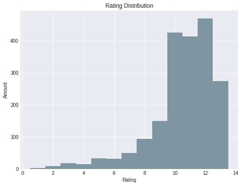

```python
# the distribution of ratings on a histogram
plt.figure(figsize=[8,6])
plt.hist(df['rating_numerator'], bins=np.arange(0.5, 14.5, 1), alpha=0.8, color='#64818e')
plt.xlabel('Rating')
plt.ylabel('Amount')
plt.title('Rating Distribution');
```

```python
# shows descriptive information about favorite counts
tweet_info['favorite_count'].describe()
```

```
count      2329.000000
mean       7575.674968
std       11757.590279
min           0.000000
25%        1319.000000
50%        3293.000000
75%        9274.000000
max      156447.000000
Name: favorite_count, dtype: float64
```

```python
# shows descriptive information about retweet counts
df['retweet_count'].describe()
```

```
count     2034.000000
mean      2587.379548
std       4528.585649
min         11.000000
25%        553.000000
50%       1222.500000
75%       2984.000000
max      77953.000000
Name: retweet_count, dtype: float64
```

**QUESTIONS**

1. The highest ratings per dog breed on average
2. The highest ratings per dog stage on average
3. The highest favorite count per dog breed on average
4. The highest favorite count per dog stage on average

```python
# groups the dataset by dog breeds and computes the average rating for each group
breed_groups = df.groupby('BreedPred1')['rating_numerator'].mean()

# filters out dog breed that appear less than 10 times
breed_groups = breed_groups[df['BreedPred1'].value_counts() > 10].sort_values(ascending=False)
breed_groups
```

```
BreedPred1
Web site                          11.789474
Eskimo dog                        11.777778
Samoyed                           11.738095
Chow                              11.636364
Golden retriever                  11.575342
Cardigan                          11.526316
Great pyrenees                    11.461538
Kelpie                            11.454545
Pembroke                          11.443182
Cocker spaniel                    11.400000
Siberian husky                    11.315789
Rottweiler                        11.294118
Blenheim spaniel                  11.272727
French bulldog                    11.240000
Pomeranian                        11.189189
Old english sheepdog              11.166667
Pekinese                          11.153846
Basset                            11.153846
Kuvasz                            11.133333
Labrador retriever                11.118280
Toy poodle                        11.105263
German shepherd                   11.000000
Malamute                          10.900000
Vizsla                            10.846154
American staffordshire terrier    10.833333
Lakeland terrier                  10.823529
Chihuahua                         10.753086
Chesapeake bay retriever          10.727273
Teddy                             10.705882
Miniature pinscher                10.652174
Border collie                     10.583333
Staffordshire bullterrier         10.555556
Shih-tzu                          10.529412
Beagle                            10.444444
Shetland sheepdog                 10.388889
West highland white terrier       10.384615
Pug                               10.315789
Italian greyhound                  9.937500
Airedale                           9.833333
Maltese dog                        9.764706
Dalmatian                          9.384615
Seat belt                          9.181818
Name: rating_numerator, dtype: float64
```

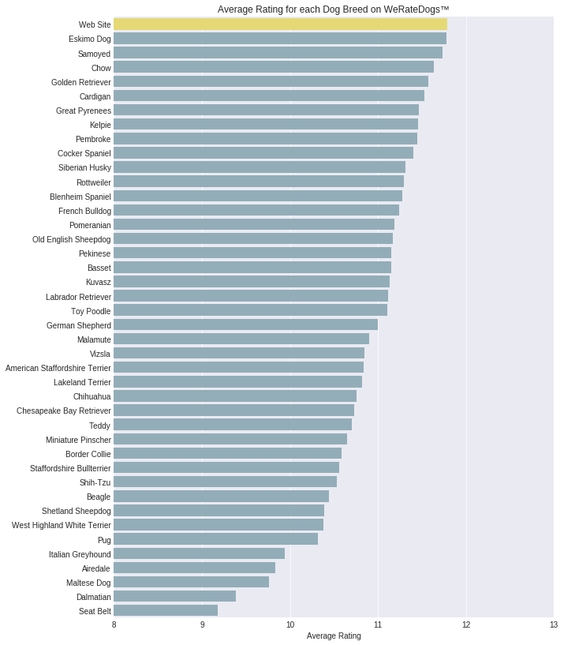

```python
# 1. The highest ratings per dog breed on average

# define axis values
x_axis = list(breed_groups)
y_axis = [i.title() for i in breed_groups.index]

# plot the bar chart
plt.figure(figsize=[10,14])
plt.xlim(8,13)
plt.xlabel('Average Rating')
plt.title('Average Rating for each Dog Breed on WeRateDogs™')
colors = ['#8dafbe' if (x < max(x_axis)) else '#f8e863' for x in x_axis]
ax = sns.barplot(x=x_axis, y=y_axis, label=y_axis, palette=colors)
plt.show();
```

```python
# groups the dataset by dog stages and computes the average rating for each group
stage_groups = df.groupby('dog_stage')['rating_numerator'].mean()

# sorts the stage groups by descending order
stage_groups = stage_groups.sort_values(ascending=False)
stage_groups
```

```
dog_stage
puppo      12.074074
floofer    12.000000
doggo      11.783133
pupper     10.623894
Name: rating_numerator, dtype: float64
```

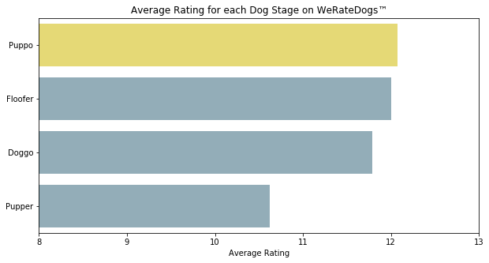

```python
# define axis values
x_axis = list(stage_groups)
y_axis = [i.title() for i in stage_groups.index]

# plot the bar chart
plt.figure(figsize=[10,5])
plt.xlim(8,13)
plt.xlabel('Average Rating')
plt.title('Average Rating for each Dog Stage on WeRateDogs™')
colors = ['#8dafbe' if (x < max(x_axis)) else '#f8e863' for x in x_axis]
ax = sns.barplot(x=x_axis, y=y_axis, label=y_axis, color="b", palette=colors)
plt.show();
```

```python
# groups the dataset by dog breeds and computes the average favorite count for each group
breed_groups_fav = df.groupby('BreedPred1')['favorite_count'].mean()

# filters out dog breed that appear less than 10 times
breed_groups_fav = breed_groups_fav[df['BreedPred1'].value_counts() > 10].sort_values(ascending=False)
breed_groups_fav
```

```
BreedPred1
French bulldog                    17513.760000
Eskimo dog                        13574.111111
Basset                            12759.615385
Cardigan                          12536.631579
Great pyrenees                    12444.307692
Web site                          12104.263158
Lakeland terrier                  11832.294118
Samoyed                           11436.809524
Pembroke                          10576.863636
Labrador retriever                10547.677419
Golden retriever                  10530.054795
Chesapeake bay retriever           9858.500000
Cocker spaniel                     9622.866667
Kelpie                             9320.272727
German shepherd                    9288.500000
Chow                               8639.068182
Border collie                      8218.083333
Italian greyhound                  7982.937500
Chihuahua                          7961.185185
Old english sheepdog               7904.166667
Shetland sheepdog                  7835.166667
Malamute                           7777.400000
Blenheim spaniel                   7719.090909
Miniature pinscher                 7627.478261
Staffordshire bullterrier          7571.055556
Rottweiler                         7346.235294
Pomeranian                         7192.594595
Seat belt                          6941.000000
Vizsla                             6857.076923
Siberian husky                     6623.631579
Pekinese                           6552.769231
Toy poodle                         5742.289474
American staffordshire terrier     5706.083333
Kuvasz                             5568.600000
West highland white terrier        5491.461538
Teddy                              5195.470588
Pug                                5126.350877
Airedale                           4830.833333
Dalmatian                          4365.538462
Beagle                             4068.055556
Shih-tzu                           3493.058824
Maltese dog                        2856.764706
Name: favorite_count, dtype: float64
```

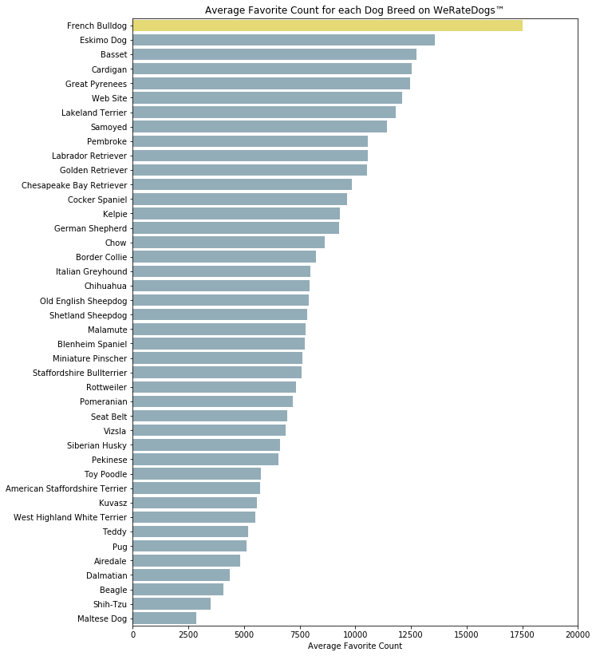

```python
# define axis values
x_axis = list(breed_groups_fav)
y_axis = [i.title() for i in breed_groups_fav.index]

# plot the bar chart
plt.figure(figsize=[10,14])
plt.xlim(0, 20000)
plt.xlabel('Average Favorite Count')
plt.title('Average Favorite Count for each Dog Breed on WeRateDogs™')
colors = ['#8dafbe' if (x < max(x_axis)) else '#f8e863' for x in x_axis]
ax = sns.barplot(x=x_axis, y=y_axis, label=y_axis, color="b", palette=colors)
plt.show();
```

```python
# groups the dataset by dog stages and computes the average favorite count for each group
stage_groups_fav = df.groupby('dog_stage')['favorite_count'].mean()

# sorts the stage groups by descending order
stage_groups_fav = stage_groups_fav.sort_values(ascending=False)
stage_groups_fav
```

```
dog_stage
puppo      20316.481481
doggo      16664.951807
floofer    12077.714286
pupper      6455.115044
Name: favorite_count, dtype: float64
```

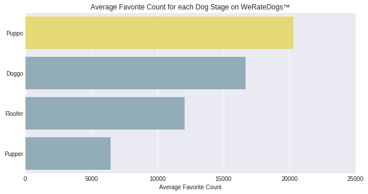